# A. phalloides RNAseq: DESeq2

Livia Oster

2025-08-08

# Extract mapping efficiency for hisat2

```r
# import data and load packages
suppressMessages(library(DESeq2))
suppressMessages(library(rmarkdown))
library(dplyr)
library(tidyr)
library(readr)

dir <- getwd()
dir
```

```
## [1] "/Volumes/Liv/Lab_projects/Amanita_phalloides/bin/Scripts_for_publication"
```

```r
dir2="/Volumes/Liv/Lab_projects/Amanita_phalloides"
# make output directories
subDir <- paste0(dir,"/Output_",Sys.Date())
dir.create(path=subDir, showWarnings = FALSE)
dir.create(paste0(subDir,"/Plots"), showWarnings = FALSE)
dir.create(paste0(subDir,"/NormCount-Graphs"), showWarnings = FALSE)
dir.create(paste0(subDir,"/NormCount-Graphs/Data"), showWarnings = FALSE)
```

```r
# path to dir containing slurm-x.out files
# slurm_out_path <- "D:/Aphalloides_rnaseq_for_leaderless/hisat2_output_msdins_array/"
slurm_out_path <- paste0(dir2,"/MSI_outputs/hisat_output")
# get list of file names
out_files <- list.files(path=slurm_out_path, pattern=".out",full.names=TRUE,recursive=TRUE)

# write a function to extract mapping efficiency

extract_hisat_mapping <- function(file_name) {
  # for debugging:
  #file_name = out_files[2]

  # open filename
  library(readr)
  temp <- read_tsv(file_name,show_col_types = FALSE)

  # Find the row index that contains "overall alignment rate"
  # this is typically third from the bottom
  index = nrow(temp)-2
  #temp2<-temp[grepl("overall alignment rate",temp[,1]),]
  mapping <- unlist(temp[index,1])



  # if this string contains %, then split by %, else print error
 if (grep("%", mapping)==TRUE) {

   # extract percent
   perc <- unlist(strsplit(mapping,split="%"))[1]

   # return this value to the console
   return(perc)

 } else print("Error: mapping rate not found")

}

# test it
extract_hisat_mapping(out_files[3])
```

```
## 2551749 reads; of these:1
##                   "43.57"
```

```r
# it works! now sapply to extract all the values

# mapping <- data.frame(Input = out_files, perc_mapping = sapply(out_files, extract_hisat_mapping))

# that didn't work because one or more files is not correctly formatted... use a loop
mapping <- data.frame(Array = list.files(path=slurm_out_path, pattern=".out",full.names=FALSE,recursive=TRUE) , perc_mapping = "")

# for (i in 1:length(out_files)) {
for (i in c(1:length(out_files))) {
  mapping[i,2] <- as.numeric(extract_hisat_mapping(out_files[i]))
}

# find array index number for each sample
mapping$Array <- gsub("\\.out", "", mapping$Array)

# keep only second half of the Array name
mapping$Array <- sub(".*_", "", mapping$Array)

# Convert Array column to numeric and reorder
mapping <- mapping %>%
  mutate(Array = as.numeric(Array)) %>%
  arrange(Array)

# now match this to the metadata file
metadata <- readxl::read_xlsx(paste0(dir,"/metadata.xlsx"),sheet="metadata")
metadata$perc_mapping <- as.numeric(mapping$perc_mapping)
metadata[,c("Sample_ID","Population","Origin","perc_mapping")]
```

```
## # A tibble: 39 × 4
##    Sample_ID Population Origin perc_mapping
##    <chr>     <chr>      <chr>         <dbl>
##  1 Drake1    Drake      CA             37.0
##  2 Drake2    Drake      CA             56.4
##  3 Drake3    Drake      CA             44.7
##  4 Drake4    Drake      CA             31.6
##  5 Drake5    Drake      CA             67.2
##  6 Drake6    Drake      CA             44.6
##  7 Drake7    Drake      CA             42.2
##  8 Drake8    Drake      CA             43.6
##  9 Drake9    Drake      CA             46.2
## 10 Pet1      Pet        CA             43.5
## # ℹ 29 more rows
```

```r
# find min, max, avg mapping rate
min(metadata$perc_mapping)
```

```
## [1] 4.31
```

```r
max(metadata$perc_mapping)
```

```
## [1] 67.16
```

```r
mean(metadata$perc_mapping)
```

```
## [1] 47.47615
```

```r
sd(metadata$perc_mapping)
```

```
## [1] 10.72104
```

```r
# print mapping
rmarkdown::paged_table(as.data.frame(metadata[,c("Sample_ID","Population","Origin","tot_reads_mill_trim","perc_mapping")]))
```

| Sample_ID | Population | Origin | tot_reads_mill_trim | perc_mapping |
| --- | --- | --- | --- | --- |
| Drake1 | Drake | CA | 74.4 | 36.97 |
| Drake2 | Drake | CA | 56.8 | 56.36 |
| Drake3 | Drake | CA | 54.4 | 44.67 |
| Drake4 | Drake | CA | 48.6 | 31.56 |
| Drake5 | Drake | CA | 76.6 | 67.16 |
| Drake6 | Drake | CA | 60.0 | 44.60 |
| Drake7 | Drake | CA | 75.2 | 42.24 |
| Drake8 | Drake | CA | 58.2 | 43.57 |
| Drake9 | Drake | CA | 38.2 | 46.18 |
| Pet1 | Pet | CA | 31.2 | 43.52 |

[output cut: 29 more lines]

```r
# save as csv
write.csv(metadata,paste0(subDir,"/metadata_plus_mapping.csv"),row.names=FALSE)
```

# Import featurecounts data & filter genes that are not expressed

```r
# set factor level; this is important for comparisons later
# group levels that are listed earlier in the list
# will be prioritized as the denominator when you do DESEq2 comparisons
# IE - the "wild type" or "control"
metadata$Origin <- factor(metadata$Origin, levels = c("EU", "CA"))


# paged_table(metadata)

# make sure all files are present
all(file.exists(metadata$Count_file))
```

```
## [1] TRUE
```

```r
# if necessary - subset to only include samples where the file exists
metadata <- metadata[file.exists(metadata$Count_file),]
metadata[,c("Sample_ID","Population","Origin","perc_mapping")]
```

```
## # A tibble: 39 × 4
##    Sample_ID Population Origin perc_mapping
##    <chr>     <chr>      <fct>         <dbl>
##  1 Drake1    Drake      CA             37.0
##  2 Drake2    Drake      CA             56.4
##  3 Drake3    Drake      CA             44.7
##  4 Drake4    Drake      CA             31.6
##  5 Drake5    Drake      CA             67.2
##  6 Drake6    Drake      CA             44.6
##  7 Drake7    Drake      CA             42.2
##  8 Drake8    Drake      CA             43.6
##  9 Drake9    Drake      CA             46.2
## 10 Pet1      Pet        CA             43.5
## # ℹ 29 more rows
```

```r
# find min, max, avg mapping rate
min(metadata$perc_mapping)
```

```
## [1] 4.31
```

```r
max(metadata$perc_mapping)
```

```
## [1] 67.16
```

```r
mean(metadata$perc_mapping)
```

```
## [1] 47.47615
```

```r
all(file.exists(metadata$Count_file))
```

```
## [1] TRUE
```

```r
# exclude pet5 (low mapping rate, 4%) and pet1-redo
metadata <- metadata[!metadata$Sample_ID %in% c("Pet1-redo","Pet5"),]
# import data - first get file names
files <- metadata$Count_file

# associate those with sample ID
names(files) <- paste(metadata$Sample_ID)

# import the featurecounts files
import_counts <- function(file_name) {
  # first line is for debugging
  # file_name = files[1]
  # extract sample prefix
  File_prefix <- unlist(strsplit(file_name,"/"))[8]

  temp <- read_tsv(file_name,comment="#",show_col_types = FALSE)
  # rename column to File_prefix
  colnames(temp)[7] <- File_prefix
  # output the column of counts
  output <- as.data.frame(temp[,7])
  rownames(output) <- temp$Geneid
  return(output)
}

# now run import_counts and cbind results together for all filenames in files
output_list <- lapply(files, import_counts)

# bind them together
cts <- as.matrix(do.call(cbind, output_list))

# rename rows to clean it up
# when I originally ran Hisat2, my gff listed GPVFFA as GPVFFAY
# I also originally indexed the duplicated core sequences as core and core_1 instead of core_1 and core_2 so I will fix these here

old_msdin <- c("GPVFFAY","AWLATCP","AWLATCP_1","IWGIGCDP","IWGIGCDP_1","LIQRPFAP","LIQRPFAP_1")

# sort these alphabetical to match row order in cts
index <- row.names(cts) %in% old_msdin
row.names(cts)[index]
```

```
## [1] "AWLATCP_1"  "LIQRPFAP"   "AWLATCP"    "GPVFFAY"    "IWGIGCDP_1"
## [6] "IWGIGCDP"   "LIQRPFAP_1"
```

```r
# now make sure new name order is the same
new_msdin <- c("AWLATCP_2","LIQRPFAP_1","AWLATCP_1","GPVFFA","IWGIGCDP_2","IWGIGCDP_1","LIQRPFAP_2")
row.names(cts)[index] <-new_msdin

# also fix messy gene IDs
row.names(cts) <- gsub("^[^-]+-|\\.m01$", "", row.names(cts))

head(cts,2)
```

```
##              10708_S250_L002 10709_S251_L002 10710_S252_L002 10711_S253_L002
## Ap.00g000010               0               0               0               0
## Ap.00g000020               0               0               0               0
##              10713_S254_L002 10716_S255_L002 10717_S256_L002 10720_S257_L002
## Ap.00g000010               0               0               0               0
## Ap.00g000020               0               0               0               0
##              10721_S279_L004 10745_S280_L004 10749_S281_L004 10751_S282_L004
## Ap.00g000010               0               0               0               0
## Ap.00g000020               0               0               0               0
##              10754_S283_L004 10763_S285_L004 10764_S286_L004 10765_S258_L002
## Ap.00g000010               0               0               0               0
## Ap.00g000020               0               0               0               0
##              10767_S259_L002 10769_S260_L002 10770_S261_L002 Aso1_S262_L002
## Ap.00g000010               0               0               0              0
## Ap.00g000020               0               0               0              0
##              Champ2_S263_L002 Doc1_S264_L002 Doc2_S265_L002 Doc3_S266_L002
## Ap.00g000010                0              0              0              0
## Ap.00g000020                0              0              0              0
##              Doc4_S287_L004 Gron7_S267_L002 Gron8_S268_L002 Gron9_S269_L002
## Ap.00g000010              0               0               0               0
## Ap.00g000020              0               0               0               0
##              Lamp1_S270_L002 Lamp2_S271_L002 Lamp4_S272_L002 Lamp5_S273_L002
## Ap.00g000010               0               0               0               0
## Ap.00g000020               0               0               0               0
##              Lamp6_S274_L002 Lamp8_S275_L002 Quill1_S276_L002 Tisza2_S277_L002
## Ap.00g000010               0               0                0                0
## Ap.00g000020               0               0                0                0
##              Tisza3_S278_L002
## Ap.00g000010                0
## Ap.00g000020                0
```

```r
# check that the row order of metadata and column order of cts match

coldata <- as.data.frame(metadata[,c("Origin","Population")])
rownames(coldata) <- metadata$File_prefix

coldata$Origin <- factor(coldata$Origin)
coldata$Population <- factor(coldata$Population)

coldata
```

```
##                  Origin Population
## 10708_S250_L002      CA      Drake
## 10709_S251_L002      CA      Drake
## 10710_S252_L002      CA      Drake
## 10711_S253_L002      CA      Drake
## 10713_S254_L002      CA      Drake
## 10716_S255_L002      CA      Drake
## 10717_S256_L002      CA      Drake
## 10720_S257_L002      CA      Drake
## 10721_S279_L004      CA      Drake
## 10745_S280_L004      CA        Pet
## 10749_S281_L004      CA        Pet
## 10751_S282_L004      CA        Pet
## 10754_S283_L004      CA        Pet
## 10763_S285_L004      CA     Picnic
## 10764_S286_L004      CA     Picnic
## 10765_S258_L002      CA     Picnic
## 10767_S259_L002      CA     Picnic
## 10769_S260_L002      CA     Picnic
## 10770_S261_L002      CA     Picnic
## Aso1_S262_L002       EU        Aso
## Champ2_S263_L002     EU      Champ
## Doc1_S264_L002       EU        Doc
## Doc2_S265_L002       EU        Doc
## Doc3_S266_L002       EU        Doc
## Doc4_S287_L004       EU        Doc
## Gron7_S267_L002      EU       Gron
## Gron8_S268_L002      EU       Gron
## Gron9_S269_L002      EU       Gron
## Lamp1_S270_L002      EU       Lamp
## Lamp2_S271_L002      EU       Lamp
## Lamp4_S272_L002      EU       Lamp
## Lamp5_S273_L002      EU       Lamp
## Lamp6_S274_L002      EU       Lamp
## Lamp8_S275_L002      EU       Lamp
## Quill1_S276_L002     EU      Quill
## Tisza2_S277_L002     EU      Tisza
## Tisza3_S278_L002     EU      Tisza
```

```r
all(rownames(coldata) %in% colnames(cts))
```

```
## [1] TRUE
```

```r
all(rownames(coldata) == colnames(cts))
```

```
## [1] TRUE
```

```r
# both of these are true!
# in case one of these was false, use the following logic:
cts <- cts[, rownames(coldata)]
all(rownames(coldata) == colnames(cts))
```

```
## [1] TRUE
```

```r
# finally - generate dds object
dds <- DESeqDataSetFromMatrix(countData = cts,
                              colData = coldata,
                              design = ~ Origin)
dds
```

```
## class: DESeqDataSet
## dim: 8779 37
## metadata(1): version
## assays(1): counts
## rownames(8779): Ap.00g000010 Ap.00g000020 ... Ap.00g068940 Ap.00g068950
## rowData names(0):
## colnames(37): 10708_S250_L002 10709_S251_L002 ... Tisza2_S277_L002
##   Tisza3_S278_L002
## colData names(2): Origin Population
```

```r
# save cts object
write.csv(cts,paste0(subDir,"/all_gene_raw_counts.csv"))

# plot expression counts for all msdins quick
msdins <- read_tsv("/Volumes/Liv/Lab_projects/Amanita_phalloides/aphalloides_reff/reff/cds_for_liv.bed", comment = "#", col_names = FALSE,show_col_types = FALSE)

msdin_cores <- msdins$X4

msdin_cts <- cts[rownames(cts) %in% msdin_cores,]
msdin_cts <- msdin_cts[order(rownames(msdin_cts)), ]
write.csv(msdin_cts,paste0(subDir,"/msdin_raw_counts.csv"))

# get average for each row
msdin_means <- rowMeans(msdin_cts)
msdin_means
```

```
##    AWLATCP_1    AWLATCP_2      AWLVDCP   FFFPPFFIPP    FFPIVFSPP   FIFPPFFIPP
## 1.048378e+02 0.000000e+00 2.210811e+01 5.567568e+00 1.135135e+01 1.864865e+00
##       FMPLAP   FNILPFMLPP    FNLFRFPYP       GPVFFA      GVILIIP     HFASFIPP
## 6.621622e+00 6.578378e+01 1.119027e+03 3.985341e+04 2.081081e+00 1.791892e+01
##    IFLAFPIPP     IFWFIYFP     IIGILLPP   IRLPPLFLPP     ISDPTAYP   IWGIGCDP_1
## 9.378378e+00 1.189189e+01 9.189189e+00 1.132432e+01 2.543243e+01 1.164865e+01
##   IWGIGCDP_2     IWGIGCNP   LFFWFWFLWP     LGRPESLP   LILLAALGIP   LIQRPFAP_1
## 4.254054e+01 6.591892e+01 2.829730e+01 1.470270e+01 4.532162e+02 2.764865e+01
##   LIQRPFAP_2   LPILPIPPLP   LRLPPFMIPP     MLGFLVLP    MLPGMVAFS   MYNPPYFLPP
## 1.251081e+02 1.081081e-01 2.181081e+01 4.535189e+04 1.378378e+00 4.216216e+00
##      SFFFPIP    TIYYLYFIP     VQKPWSRP
## 4.225981e+04 2.648649e+00 5.810811e+00
```

```r
# get number of samples with a count of zeros for each msdin
num_zeros <- rowSums(msdin_cts == 0)
num_zeros
```

```
##  AWLATCP_1  AWLATCP_2    AWLVDCP FFFPPFFIPP  FFPIVFSPP FIFPPFFIPP     FMPLAP
##          0         37          1          6          0         13          1
## FNILPFMLPP  FNLFRFPYP     GPVFFA    GVILIIP   HFASFIPP  IFLAFPIPP   IFWFIYFP
##          0          0          1         34          2          0          0
##   IIGILLPP IRLPPLFLPP   ISDPTAYP IWGIGCDP_1 IWGIGCDP_2   IWGIGCNP LFFWFWFLWP
##         21          6          1          1          1          0          0
##   LGRPESLP LILLAALGIP LIQRPFAP_1 LIQRPFAP_2 LPILPIPPLP LRLPPFMIPP   MLGFLVLP
##          2          0          0          0         36          9          0
##  MLPGMVAFS MYNPPYFLPP    SFFFPIP  TIYYLYFIP   VQKPWSRP
##         13          7          0          8          2
```

```r
# print this:
summary_df <- data.frame(
  mean = msdin_means,
  num_zeros = num_zeros
)

# remove low-count genes that have a mean count below 5
# keep <- rowSums(counts(dds)) >= 10
keep <- rowMeans(counts(dds)) >= 5

sum(keep)
```

```
## [1] 8096
```

```r
# total genes - counting msdins
length(dds)
```

```
## [1] 8779
```

```r
# total genes - excluding msdins
length(dds) - length(msdin_cores)
```

```
## [1] 8746
```

```r
# count number of msdins (out of 33) that are above 5
sum(msdin_means >= 5 )
```

```
## [1] 26
```

```r
# percent
sum(msdin_means >= 5 ) / length(msdin_cores) * 100
```

```
## [1] 78.78788
```

```r
# total genes detected - excluding msdins
sum(keep) - sum(msdin_means >= 5 )
```

```
## [1] 8070
```

```r
# percent
(sum(keep) - sum(msdin_means >= 5 )) / (length(dds) - length(msdin_cores)) * 100
```

```
## [1] 92.27075
```

```r
# find percentage of genes that have been kept after applying filter for low counts
sum(keep) / length(dds) * 100
```

```
## [1] 92.22007
```

```r
# now subset your dds object to keep only "keep" rows
dds <- dds[keep,]
```

# Run DESeq2

```r
dds <- DESeq(dds)
```

```
## -- replacing outliers and refitting for 93 genes
## -- DESeq argument 'minReplicatesForReplace' = 7
## -- original counts are preserved in counts(dds)
```

```r
res = results(dds, alpha=0.05, independentFiltering=FALSE, cooksCutoff=TRUE)
summary(res)
```

```
##
## out of 8095 with nonzero total read count
## adjusted p-value < 0.1
## LFC > 0 (up)       : 2490, 31%
## LFC < 0 (down)     : 2842, 35%
## outliers [1]       : 0, 0%
## low counts [2]     : 0, 0%
## (mean count < 0)
## [1] see 'cooksCutoff' argument of ?results
## [2] see 'independentFiltering' argument of ?results
```

```r
resultsNames(dds)
```

```
## [1] "Intercept"       "Origin_CA_vs_EU"
```

```r
# save results
resOrdered <- res[order(res$pvalue),]
# add column to indicate significance
resOrdered$significant_hits <- with(resOrdered, abs(log2FoldChange) > 1 & padj < 0.05)


write.csv(as.data.frame(resOrdered),
          file=paste0(subDir,"/DESeq_output.csv"))
```

# QC results and generate first-pass plots

## Volcano plots

```r
# summarize results from dds
# group1 will be the numerator (ie, treatment)
# group2 will be denominator (ie, control)
# gene_list is the list of genes you want to annotate on the volcano plot

make_volcano <- function(group1,group2,gene_list = msdins$X4) {
  # group1 = "CA"
  # group2 = "EU"
  # gene_list = msdins$X4
  print(paste0(group1," vs ",group2))

  res <- results(dds, contrast=c("Origin", group1, group2), alpha=0.05, independentFiltering=FALSE, cooksCutoff=TRUE)

  # now save deseq results as a dataframe
  deseqoutput <- as.data.frame(res)

  # plot it
  library(EnhancedVolcano)
  EnhancedVolcano(deseqoutput,
                  lab = rownames(res),
                  selectLab = gene_list,
                  title = paste0(group1," vs. ",group2),
                  subtitle = bquote(
                    italic("")),
                  caption = "",
                  x = 'log2FoldChange',
                  y = 'padj',
                  pCutoff = 0.05,
                  FCcutoff = 1,
                  ylab = bquote(~-Log[10] ~ italic("Adj. P value")),
                  legendPosition = 'bottom',
                  typeConnectors ="closed",
                  drawConnectors = TRUE,
                  widthConnectors = 1,
                  arrowheads = FALSE,
                  labSize = 4,
                  max.overlaps = 15,
                  lengthConnectors = unit(0.02, "npc")) +
    ggplot2::coord_cartesian(xlim=c(-6, 6), ylim=c(0,30)) +
    ggplot2::scale_x_continuous(breaks=seq(-5,5, 1))

  ggsave(paste0(subDir,"/Plots/",group1,"_vs_",group2,"_volcano.png"),
         units ="in",
         width = 10,
         height = 10)

  summary(res)

  # # shrink log fold changes
  # resLFC <- lfcShrink(dds, coef=paste0("Group_",group2,"_vs_",group1), type="apeglm")
  # resLFC
  #
  # # use MA plot to visualize log2 fold changes
  # plotMA(res,ylim=c(-2,2))
  #
  # # plot the shrunken LFC which should remove noise from low count genes
  # plotMA(resLFC, ylim=c(-2,2))
}
```

```r
make_volcano(group2 = "EU",
             group1 = "CA")
```

```
## [1] "CA vs EU"
```

```
## replace the existing one.
```

```
##
## out of 8095 with nonzero total read count
## adjusted p-value < 0.1
## LFC > 0 (up)       : 2490, 31%
## LFC < 0 (down)     : 2842, 35%
## outliers [1]       : 0, 0%
## low counts [2]     : 0, 0%
## (mean count < 0)
## [1] see 'cooksCutoff' argument of ?results
## [2] see 'independentFiltering' argument of ?results
```

## Plot counts for single genes

```r
# make a plot for every gene and save it in a folder...
make_count_plot <- function(geneID) {
  # geneID = paste0(msdins$X4[10],".m01")
  gene <- plotCounts(dds, gene = geneID, intgroup = "Origin", returnData = TRUE)

  # Define color palette for Origin
  gene$Origin <- factor(gene$Origin, levels = c("CA",
                                                    "EU"))

  # also add pop information
  gene$Population <- metadata$Population

  gene$Population <- factor(gene$Population, levels = c("Drake",
                                                            "Pet",
                                                            "Picnic",
                                                            "Aso",
                                                            "Champ",
                                                            "Doc",
                                                            "Gron",
                                                            "Lamp",
                                                            "Quill",
                                                            "Tisza"))

  # genotype_colors <- c("#717568","#3F4739", "#FF01FB", "#0CCA4A","grey40","grey60")
  # colors for origin:
  # genotype_colors <- c("#FE4A49", "#2292A4")

genotype_colors <- c("#723D00","#fb8500","#ffb703",
                     "#023047","#0C556E","#177995","#219EBC","#5CB7CE","#96CFE0","#D1E8F2")

ggplot(data=gene,aes(x=Origin,y=count)) +
  geom_point(aes(colour = Population), size = 4, position = position_jitter(w = 0.3, h = 0)) +
  # add mean line
  stat_summary(fun= mean, fun.min=mean, fun.max=mean, geom="crossbar", width=0.5, linewidth=1,color="black") +
  # add error bars
  stat_summary(fun.data=mean_se, fun.args = list(mult=1), geom="errorbar", width=0.2, linewidth=1,color="black") +
  theme_classic()  +
  scale_color_manual(values = genotype_colors) +
  theme(legend.position = "none",
        text = element_text(size = 16),
        axis.text.x = element_text(angle = 45, hjust = 1, size = 14)) +
  ylab("Normalized count") +
  ggtitle(paste0(geneID))

  # save graph
  ggsave(paste0(geneID,"_normalized_counts.png"),
         device="png",dpi="print",
         units = "in", width = 5, height = 3,
         path=paste0(subDir,"/NormCount-Graphs"))
  # save data table
  write.csv(gene,paste0(subDir,"/NormCount-Graphs/Data/",geneID,".csv"))
}
```

```r
# MSDINs, leadered and leaderless:
list <- msdins$X4

# first see which of these genes have any counts at all
# get counts matrix for all genes
counts <- counts(dds, normalized=TRUE)
# find list of RiPPs also in count matrix
list <- intersect(list, rownames(counts))

# loop through gene list
for(i in 1:length(list)) {
  genename = list[i]
  make_count_plot(geneID=genename) # takes ~1.5 hr to run on 9000 genes
}

# in the future we could also plot a handful of housekeeping genes

# next: generate facet_wrap graph for all MSDINS

# also: violin plot for vsd expression of all
```

## Variance stabilizing transformations

More info can be found at [DESeq2 Bioconductor tutorial](http://bioconductor.org/packages/devel/bioc/vignettes/DESeq2/inst/doc/DESeq2.html#exploring-and-exporting-results):

These figures plot the standard deviation of transformed data. A flat curve of the square root of variance over the mean is ideal.

```r
# Extracting transformed values
vsd <- vst(dds, blind=FALSE)
ntd <- normTransform(dds)

# extract the matrix of normalized values.
head(assay(vsd), 3)
```

```
##              10708_S250_L002 10709_S251_L002 10710_S252_L002 10711_S253_L002
## Ap.00g000050        3.931201        5.572686        4.894666        4.955907
## Ap.00g000070        4.385691        4.583703        4.452363        4.896566
## Ap.00g000080        3.573526        4.285382        3.887994        3.967977
##              10713_S254_L002 10716_S255_L002 10717_S256_L002 10720_S257_L002
## Ap.00g000050        5.840707        3.892063        4.118567        3.669032
## Ap.00g000070        4.684207        3.824621        4.801341        4.888208
## Ap.00g000080        5.095938        3.824621        3.702245        3.557715
##              10721_S279_L004 10745_S280_L004 10749_S281_L004 10751_S282_L004
## Ap.00g000050        3.139013        3.485095        4.743158        5.164954
## Ap.00g000070        4.225513        4.386186        4.675340        4.515019
## Ap.00g000080        3.139013        3.835854        3.948250        3.068117
##              10754_S283_L004 10763_S285_L004 10764_S286_L004 10765_S258_L002
## Ap.00g000050        6.278687        3.598048        4.785243        4.772664
## Ap.00g000070        4.518498        4.422308        4.307726        4.853514
## Ap.00g000080        4.164186        4.079780        4.154621        4.074898
##              10767_S259_L002 10769_S260_L002 10770_S261_L002 Aso1_S262_L002
## Ap.00g000050        4.477160        3.784712        4.042488       4.449782
## Ap.00g000070        4.657381        4.695893        4.781370       4.301738
## Ap.00g000080        4.017005        4.521756        3.947587       5.301503
##              Champ2_S263_L002 Doc1_S264_L002 Doc2_S265_L002 Doc3_S266_L002
## Ap.00g000050         3.968394       4.001065       5.165233       5.423174
## Ap.00g000070         4.741225       4.068286       4.336842       5.515404
## Ap.00g000080         4.553707       4.250250       3.900342       5.969678
##              Doc4_S287_L004 Gron7_S267_L002 Gron8_S268_L002 Gron9_S269_L002
## Ap.00g000050       4.338955        5.966887        6.790239        7.678984
## Ap.00g000070       5.083751        5.143560        4.769615        4.509287
## Ap.00g000080       5.662030        4.737057        4.360035        4.104067
##              Lamp1_S270_L002 Lamp2_S271_L002 Lamp4_S272_L002 Lamp5_S273_L002
## Ap.00g000050        4.537753        4.261712        3.851713        4.575055
## Ap.00g000070        4.867496        4.916421        4.129432        4.451162
## Ap.00g000080        4.656917        4.261712        3.851713        5.292489
##              Lamp6_S274_L002 Lamp8_S275_L002 Quill1_S276_L002 Tisza2_S277_L002
## Ap.00g000050        3.646494        8.055757         3.954890         4.509872
## Ap.00g000070        5.285198        5.044768         3.011301         4.436541
## Ap.00g000080        5.196493        6.014828         4.370828         3.875502
##              Tisza3_S278_L002
## Ap.00g000050         4.739591
## Ap.00g000070         4.359752
## Ap.00g000080         5.035299
```

```r
# plots
library(vsn)
msd_dds <- meanSdPlot(assay(dds))
```

```r
msd_vsd <- meanSdPlot(assay(vsd))
```

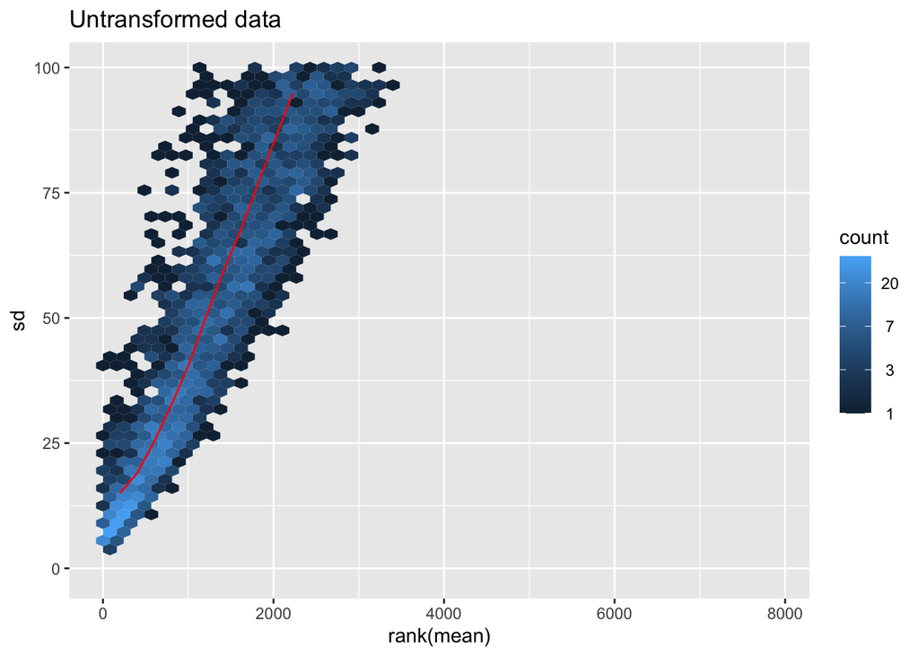

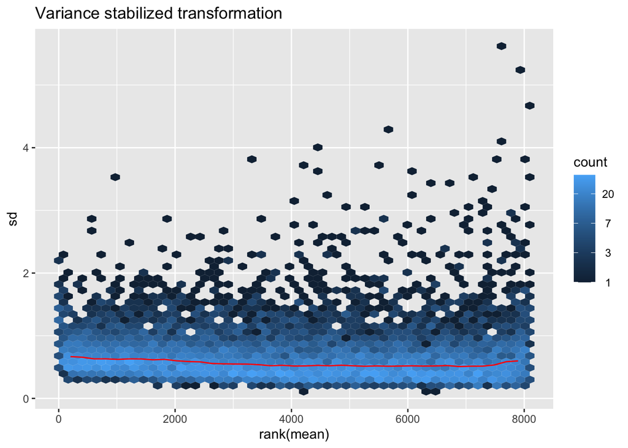

```r
msd_dds$gg + ggtitle("Untransformed data") + ylim(-1,100)
msd_vsd$gg + ggtitle("Variance stabilized transformation")
```

## Supervised clustering

```r
# find 15 genes with highest expression levels from dds
select <- order(rowMeans(counts(dds,normalized=TRUE)),
                decreasing=TRUE)[1:15]

# make new data frame with only Population stage info
df <- as.data.frame(colData(dds)[,c("Population")])
colnames(df) <- c("Population")
#samples <- colnames(assay(ntd))
samples <- metadata$Sample_ID
rownames(df) <- samples

# heatmap of variance stabilized data
library(pheatmap)

# extract data
mat <- assay(vsd)[select,]
top15 <- row.names(mat)
colnames(mat) <- metadata$Sample_ID

# remove the random prefix and suffixes
row.names(mat) <- gsub("^[^-]+-|\\.m01$", "", row.names(mat))
row.names(mat)
```

```
##  [1] "Ap.00g078360" "Ap.00g054880" "Ap.00g019870" "Ap.00g054640" "Ap.00g057760"
##  [6] "MLGFLVLP"     "Ap.00g068810" "Ap.00g039900" "SFFFPIP"      "Ap.00g008070"
## [11] "GPVFFA"       "Ap.00g078370" "Ap.00g011790" "Ap.00g001030" "Ap.00g063180"
```

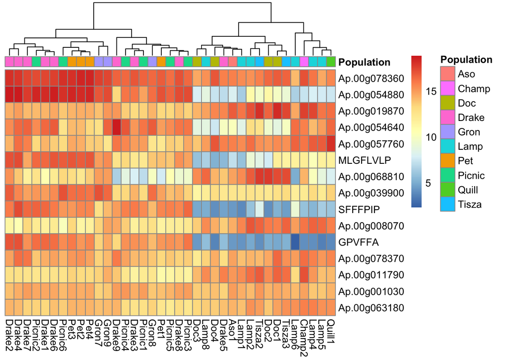

```r
pheatmap(mat, cluster_rows=FALSE,
         show_rownames=TRUE,
         cluster_cols=TRUE, annotation_col=df)
```

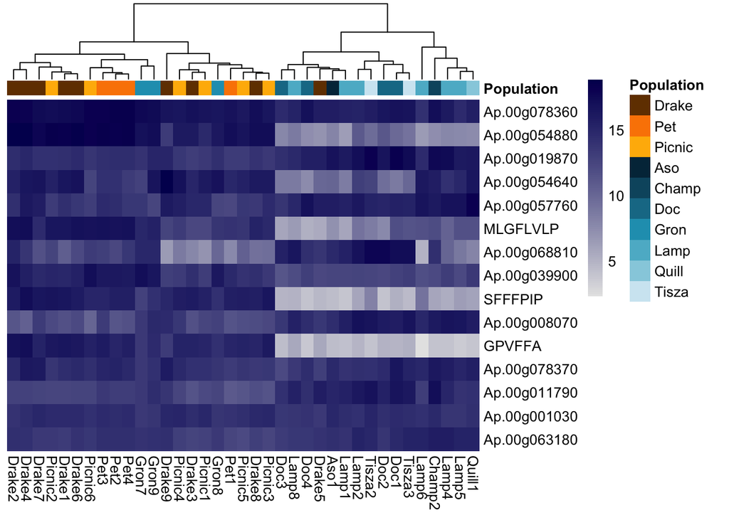

```r
# also make heatmap of genes with custom colors
genotype_colors <- c("#723D00","#fb8500","#ffb703",
                     "#023047","#0C556E","#177995","#219EBC","#5CB7CE","#96CFE0","#D1E8F2")

annotation_colors <- list(Population = setNames(genotype_colors, unique(df$Population)))

# Define your custom color scale (from dark blue to aqua)
my_colors <- colorRampPalette(c("grey90","#03045e"))(100)


pheatmap(mat, cluster_rows=FALSE,
         show_rownames=TRUE,
         cluster_cols=TRUE,
         annotation_col=df,
         annotation_colors = annotation_colors,
         legend=TRUE,
         color=my_colors,
         border_color = "transparent",
         fontsize_row = 10,  # Row label font size
         fontsize_col = 10)
```

##Do we know any functional information about the highly expressed transcripts?

I used the following code to extract all the protein sequences that match the highly expressed genes, and then I used the online NCBI blastp to search human and Aspergillus fumigatus for closely related proteins with known functions or names.

Next let’s figure out which genes are highly expressed…

```r
library(rtracklayer)
library(Biostrings)
library(GenomicFeatures)
# Define file paths
genome_file <- "/Volumes/Liv/Lab_projects/Amanita_phalloides/aphalloides_reff/reff/10511_Aphal_PT_AllpathsLG_LINKS_jelly_pilon.fna"

# make sure chromosomes are assigned correctly
library(Rsamtools)

# Load Genome Sequence
genome_fa <- FaFile(genome_file)
class(genome)
```

```
## [1] "standardGeneric"
## attr(,"package")
## [1] "methods"
```

```r
names(genome)
```

```r
# Load GFF3
gff <- paste0(dir,"/aphal_reff_with_msdins.gff3")
gff_sorted <- read_tsv(gff, comment = "#", col_names = FALSE,show_col_types = FALSE)

colnames(gff_sorted) <- c("seqid", "source", "type", "start", "end", "score", "strand", "phase", "attributes")

sum(is.na(gff_sorted$start))  # Count missing start positions
```

```
## [1] 0
```

```r
sum(is.na(gff_sorted$end))
```

```
## [1] 0
```

```r
# Create TxDb from GFF3
options(scipen = 999)
txdb <- makeTxDbFromGFF(gff, format="gff3")
```

```
## Import genomic features from the file as a GRanges object ...
```

```
## OK
```

```
## Prepare the 'metadata' data frame ... OK
## Make the TxDb object ...
```

```
## OK
```

```r
# save txdb object
saveDb(txdb, file = paste0(dir,"/txdb.sqlite"))
```

```
## TxDb object:
## # Db type: TxDb
## # Supporting package: GenomicFeatures
## # Data source: /Volumes/Liv/Lab_projects/Amanita_phalloides/bin/Scripts_for_publication/aphal_reff_with_msdins.gff3
## # Organism: NA
## # Taxonomy ID: NA
## # miRBase build ID: NA
## # Genome: NA
## # Nb of transcripts: 8812
## # Db created by: txdbmaker package from Bioconductor
## # Creation time: 2025-08-08 10:55:51 -0500 (Fri, 08 Aug 2025)
## # txdbmaker version at creation time: 1.4.2
## # RSQLite version at creation time: 2.4.2
## # DBSCHEMAVERSION: 1.2
```

```r
# Extract CDS sequences from genome
transcripts <- exonsBy(txdb, by="tx", use.names=TRUE)

cds_seqs <- extractTranscriptSeqs(genome_fa, transcripts)

# find cds that might not contain complete codons (length 3)
invalid_cds <- names(cds_seqs)[width(cds_seqs) %% 3 != 0]
invalid_cds
```

```
##   [1] "26557-Ap.00g000010.m01" "26557-Ap.00g002410.m01" "26557-Ap.00g069340.m01"
##   [4] "26557-Ap.00g069850.m01" "26557-Ap.00g074640.m01" "26557-Ap.00g074690.m01"
##   [7] "26557-Ap.00g028120.m01" "26557-Ap.00g077690.m01" "26557-Ap.00g078010.m01"
##  [10] "AWLATCP_2"              "AWLATCP_2.m01"          "FNLFRFPYP"
##  [13] "FNLFRFPYP.m01"          "26557-Ap.00g078580.m01" "26557-Ap.00g078590.m01"
##  [16] "LIQRPFAP_1"             "LIQRPFAP_1.m01"         "26557-Ap.00g028540.m01"
##  [19] "26557-Ap.00g078640.m01" "26557-Ap.00g079210.m01" "26557-Ap.00g079670.m01"
##  [22] "26557-Ap.00g080450.m01" "26557-Ap.00g081210.m01" "SFFFPIP"
##  [25] "SFFFPIP.m01"            "26557-Ap.00g031270.m01" "LFFWFWFLWP"
##  [28] "LFFWFWFLWP.m01"         "26557-Ap.00g030190.m01" "26557-Ap.00g082400.m01"
##  [31] "26557-Ap.00g082490.m01" "26557-Ap.00g082500.m01" "26557-Ap.00g082510.m01"
##  [34] "26557-Ap.00g082650.m01" "FFFPPFFIPP"             "FFFPPFFIPP.m01"
##  [37] "MYNPPYFLPP"             "MYNPPYFLPP.m01"         "VQKPWSRP"
##  [40] "VQKPWSRP.m01"           "LGRPESLP"               "LGRPESLP.m01"
##  [43] "IRLPPLFLPP"             "IRLPPLFLPP.m01"         "LRLPPFMIPP"
```

[output cut: 38 more lines]

```r
# check for any invalid bases in the CDS sequences
invalid_bases <- grepl("[^ATCG]", as.character(cds_seqs))
invalid_seqs <- cds_seqs[invalid_bases]
invalid_seqs
```

```
## DNAStringSet object of length 8:
##     width seq                                               names
## [1]   633 ATGCAGAATCAACCTTCCGGTTC...TCTTAATTGATTTGATGCTATAA 26557-Ap.00g02881...
## [2]  1416 ATGTCCACGCTCGACGCGCTCTT...AGTTTGGGATCGTTTATGGCTAA 26557-Ap.00g08106...
## [3]   165 ATGGGTTCGTATTCTTCCAAATA...CTACCAAAGGCACTGATTTCTAG 26557-Ap.00g03087...
## [4]  1176 ATGACCGAAACCCCCCATGGCAG...AAGCAATGTTCTGGAAATATTAG 26557-Ap.00g08395...
## [5]   861 ATGGTTGATCCTGTTCCCAATGT...GAGATCTAATAANCAAAATATAG 26557-Ap.00g04095...
## [6]   957 ATGGATGTTCCCGTTGCACAGCA...GTCGNGATGCTGAGAGCCAATAG 26557-Ap.00g00932...
## [7]   915 ATGAACACCAAACGTGTCACAGA...AACGACCGTCCATGGACGGTTAA 26557-Ap.00g05106...
## [8]  2004 ATGACGCAGCGACCAGACGCTCT...CCGTAAAATATCTGTTGAGTTGA 26557-Ap.00g01398...
```

```r
# remove seqs with invalid bases
cds_seqs <- cds_seqs[!invalid_bases]

# Translate to protein sequences
protein_seqs <- translate(cds_seqs)
head(names(protein_seqs))
```

```
## [1] "26557-Ap.00g000010.m01" "26557-Ap.00g000020.m01" "26557-Ap.00g000030.m01"
## [4] "26557-Ap.00g000050.m01" "26557-Ap.00g000060.m01" "26557-Ap.00g000100.m01"
```

```r
# fix names - remove "26557-" and ".m*"
names(protein_seqs) <- sub("^26557-", "", names(protein_seqs))
names(protein_seqs) <- sub("\\.m.*$", "", names(protein_seqs))

head(names(protein_seqs))
```

```
## [1] "Ap.00g000010" "Ap.00g000020" "Ap.00g000030" "Ap.00g000050" "Ap.00g000060"
## [6] "Ap.00g000100"
```

```r
# Write to a FASTA file
writeXStringSet(protein_seqs, paste0(dir,"/aphal_proteins.fasta"))

cat("Protein sequences saved to aphal_proteins.fasta\n")
```

```
## Protein sequences saved to aphal_proteins.fasta
```

### Now extract highly expressed genes

```r
top15
```

```
##  [1] "Ap.00g078360" "Ap.00g054880" "Ap.00g019870" "Ap.00g054640" "Ap.00g057760"
##  [6] "MLGFLVLP"     "Ap.00g068810" "Ap.00g039900" "SFFFPIP"      "Ap.00g008070"
## [11] "GPVFFA"       "Ap.00g078370" "Ap.00g011790" "Ap.00g001030" "Ap.00g063180"
```

```r
# extract from fasta
# if reading in a new fasta, use the following:
# fasta <- paste0(dir,"/aphal_proteins.fasta")
# #BiocManager::install("Biostrings")
#
# library(Biostrings)
# fasta_seqs <- readAAStringSet(fasta)

# Match names in FASTA with entries in top15
matched_seqs <- unique(protein_seqs[names(protein_seqs) %in% top15])
# remove duplicates - msdins are showing up twice ...
matched_seqs
```

```
## AAStringSet object of length 15:
##      width seq                                              names
##  [1]   127 MRDRDTGRSRGFGFVTYSTNDEA...QGGYGGGGYSQGYQQGSGFGY* Ap.00g001030
##  [2]   468 MVASKTSILVAAVALGAASVYAA...SLGLDEDYFTKRFYDEDVSEF* Ap.00g078360
##  [3]   477 MVASKTSIIVAAVALGAATAYAA...SLGLDLDYFTKRFYDEDGLEY* Ap.00g078370
##  [4]    35 MSDINAARLPSFFFPIPCISDDIEMVLTRGERPLL              SFFFPIP
##  [5]    34 MSDVNTIRIPGPVFFAYVGDEVDNVLRSGERPFL               GPVFFA
##  ...   ... ...
## [11]   184 MVKFTSVFFVFATLALSVVASPV...AMRDKETVDAAFKQVIDYYSH* Ap.00g054880
## [12]   324 MPSPTVLRLLALASLALLAALGP...NRLLGSNGQPTSLGWYYVNQY* Ap.00g019870
## [13]   294 MQKSLILSVLLAFSLVAMCAPAV...TGFDEKITAVSTYWGYLRKST* Ap.00g057760
## [14]   233 MFFNRFFVLFAIVLYSLALITPH...DNLADEAVGRLFNIHWHWLFV* Ap.00g063180
## [15]   779 MYSLHYFLFLCTILSYTGVVFGL...AGVINQSGNANGYASTVTAWY* Ap.00g068810
```

```r
# save
writeXStringSet(matched_seqs, filepath = paste0(dir,"/top15_sequences.fasta"))
```

## PCA / unsupervised clustering

A great interactive explanation of PCA plots is [here](https://bioboot.github.io/bggn213_F20/class-material/pca/)

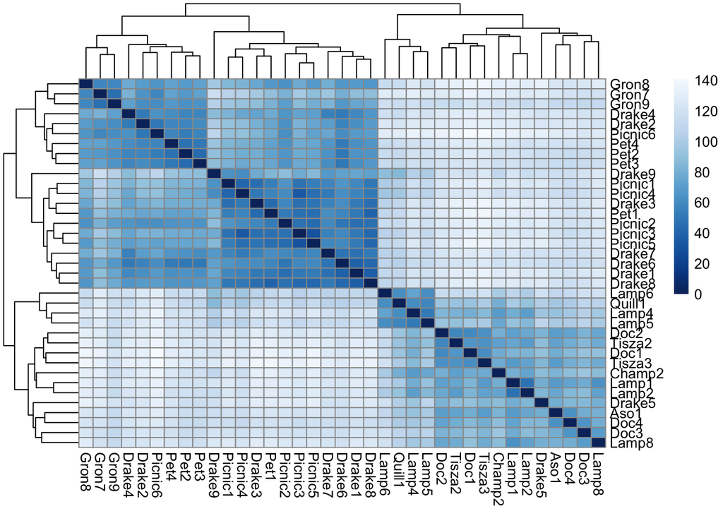

```r
# find distances between samples
sampleDists <- dist(t(assay(vsd)))

# reformat distances
sampleDistMatrix <- as.matrix(sampleDists)

# make row and column names the same as sample IDs
rownames(sampleDistMatrix) <- rownames(df)
colnames(sampleDistMatrix) <- rownames(df)

# generate some nice colors
library(RColorBrewer)
colors <- colorRampPalette( rev(brewer.pal(9, "Blues")) )(255)

# plot it
pheatmap(sampleDistMatrix,
         clustering_distance_rows=sampleDists,
         clustering_distance_cols=sampleDists,
         col=colors)
```

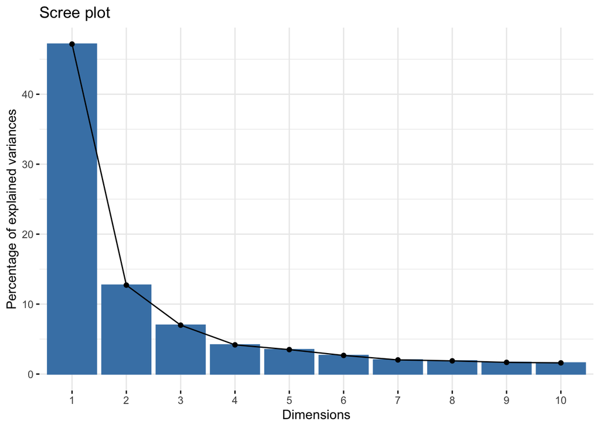

```r
# next lets generate a PCA plot on variance stabilized data
vsd_out <- assay(vsd)

# run PCA analysis
pca <- prcomp(t(vsd_out))

# plot scree
library(factoextra)
fviz_eig(pca)
```

```r
# Create data frame with metadata and PC3 and PC4 values for input to ggplot
pcaData <- cbind(metadata[,c(2:5,8,13,15,18)], pca$x)

# Define color palette for genotypes
pcaData$Origin <- factor(pcaData$Origin, levels = c("CA",
                                                    "EU"))
genotype_colors <- c("#723D00","#fb8500","#ffb703",
                     "#023047","#0C556E","#177995","#219EBC","#5CB7CE","#96CFE0","#D1E8F2")

genotype_colors <- c("#fb8500", "#5CB7CE")

# find percent variance for PC1 and PC2
# summary of variance
pcasummary <- summary(pca)
pcasummary
```

```
## Importance of components:
##                            PC1     PC2      PC3      PC4      PC5      PC6
## Standard deviation     49.7044 25.8066 19.13221 14.78744 13.52954 11.80978
## Proportion of Variance  0.4717  0.1272  0.06989  0.04175  0.03495  0.02663
## Cumulative Proportion   0.4717  0.5989  0.66875  0.71051  0.74546  0.77209
##                             PC7     PC8     PC9    PC10    PC11   PC12    PC13
## Standard deviation     10.29650 9.94409 9.35800 9.14385 8.16263 8.0259 7.62119
## Proportion of Variance  0.02024 0.01888 0.01672 0.01596 0.01272 0.0123 0.01109
## Cumulative Proportion   0.79233 0.81121 0.82793 0.84389 0.85661 0.8689 0.88000
##                           PC14    PC15    PC16    PC17    PC18    PC19   PC20
## Standard deviation     7.31282 7.06540 6.88098 6.48477 6.33989 6.11415 5.9695
## Proportion of Variance 0.01021 0.00953 0.00904 0.00803 0.00767 0.00714 0.0068
## Cumulative Proportion  0.89021 0.89975 0.90879 0.91681 0.92449 0.93163 0.9384
##                           PC21    PC22    PC23    PC24    PC25    PC26    PC27
## Standard deviation     5.92059 5.63675 5.56342 5.07650 4.98911 4.78476 4.60256
## Proportion of Variance 0.00669 0.00607 0.00591 0.00492 0.00475 0.00437 0.00404
## Cumulative Proportion  0.94512 0.95119 0.95710 0.96202 0.96677 0.97114 0.97519
##                           PC28   PC29    PC30    PC31    PC32    PC33    PC34
## Standard deviation     4.53083 4.4004 4.21240 4.02068 3.99395 3.62851 3.34748
## Proportion of Variance 0.00392 0.0037 0.00339 0.00309 0.00305 0.00251 0.00214
## Cumulative Proportion  0.97911 0.9828 0.98619 0.98928 0.99233 0.99484 0.99698
##                           PC35   PC36                PC37
## Standard deviation     2.91502 2.7063 0.00000000000004633
## Proportion of Variance 0.00162 0.0014 0.00000000000000000
## Cumulative Proportion  0.99860 1.0000 1.00000000000000000
```

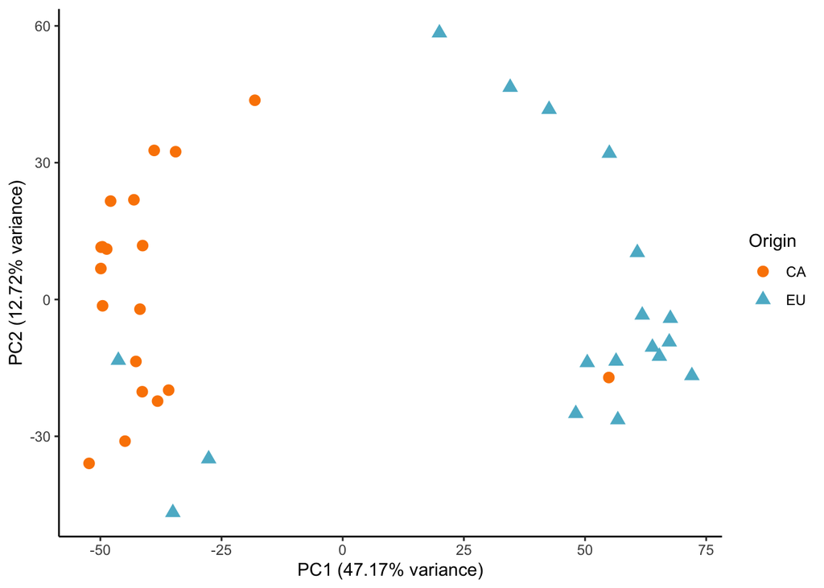

```r
pc1var <- round(pcasummary$importance[2],digits = 4) * 100
pc2var <- round(pcasummary$importance[5],digits = 4) * 100
pc3var <- round(pcasummary$importance[8],digits = 4) * 100
pc4var <- round(pcasummary$importance[11],digits = 4) * 100


# plot PC1 and 2
ggplot(pcaData,aes(x=PC1, y=PC2, color = Origin, shape = Origin)) +
  geom_point(size=3) +
  theme_classic() +
  scale_color_manual(values = genotype_colors) +
  xlab(paste0("PC1 (",pc1var,"% variance)")) +
  ylab(paste0("PC2 (",pc2var,"% variance)"))
```

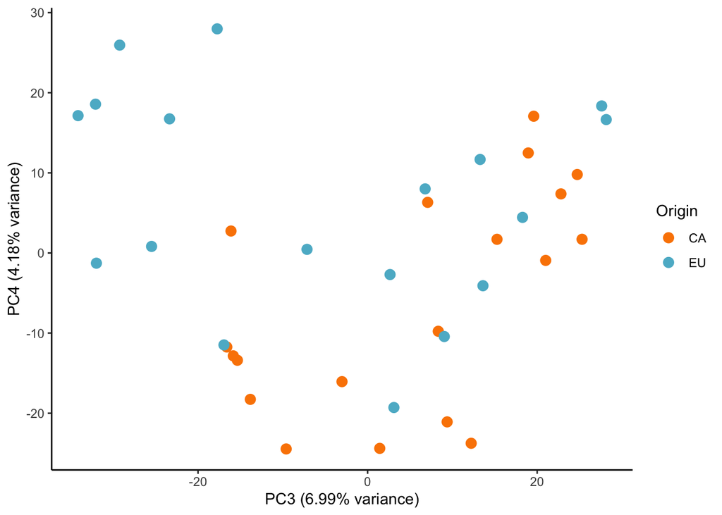

```r
ggsave("PCA_plot_pc12_origin.png",
       path = paste0(subDir,"/Plots/"),
       units="in",
       width = 6, height = 5)

# plot PC3 and 4
ggplot(pcaData,aes(x=PC3, y=PC4, color = Origin, size = Origin)) +
  geom_point(size=3) +
  theme_classic() +
  scale_color_manual(values = genotype_colors) +
  xlab(paste0("PC3 (",pc3var,"% variance)")) +
  ylab(paste0("PC4 (",pc4var,"% variance)"))
```

```r
ggsave("PCA_plot_pc34_origin.png",
       path = paste0(subDir,"/Plots/"),
       units="in",
       width = 6, height = 5)

# also plot where colors indicate population & shape indicates Origin

# deduplicate
t <- unique(metadata[,c(4,8)])
t
```

```
## # A tibble: 10 × 2
##    Population Origin
##    <chr>      <fct>
##  1 Drake      CA
##  2 Pet        CA
##  3 Picnic     CA
##  4 Aso        EU
##  5 Champ      EU
##  6 Doc        EU
##  7 Gron       EU
##  8 Lamp       EU
##  9 Quill      EU
## 10 Tisza      EU
```

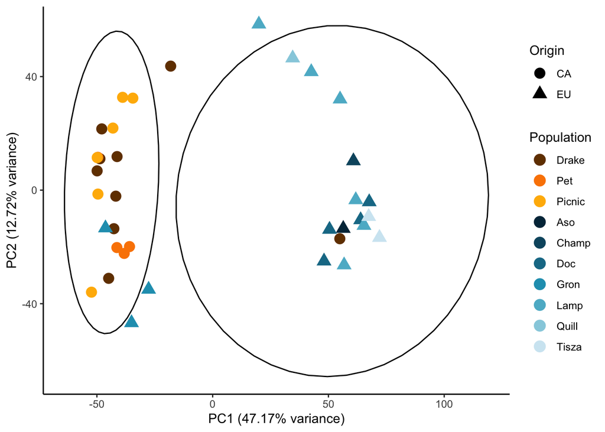

```r
pcaData$Population <- factor(pcaData$Population, levels = c("Drake",
                                                            "Pet",
                                                            "Picnic",
                                                            "Aso",
                                                            "Champ",
                                                            "Doc",
                                                            "Gron",
                                                            "Lamp",
                                                            "Quill",
                                                            "Tisza"))
# first 3 are CA, last 7 are EU
genotype_colors <- c("#723D00","#fb8500","#ffb703",
                     "#023047","#0C556E","#177995","#219EBC","#5CB7CE","#96CFE0","#D1E8F2")


ggplot(pcaData,aes(x=PC1, y=PC2, color = Population, shape = Origin)) +
  geom_point(size=4) +
  theme_classic() +
  scale_color_manual(values = genotype_colors) +
stat_ellipse(aes(group = Origin), colour = "black")+
  xlab(paste0("PC1 (",pc1var,"% variance)")) +
  ylab(paste0("PC2 (",pc2var,"% variance)"))
```

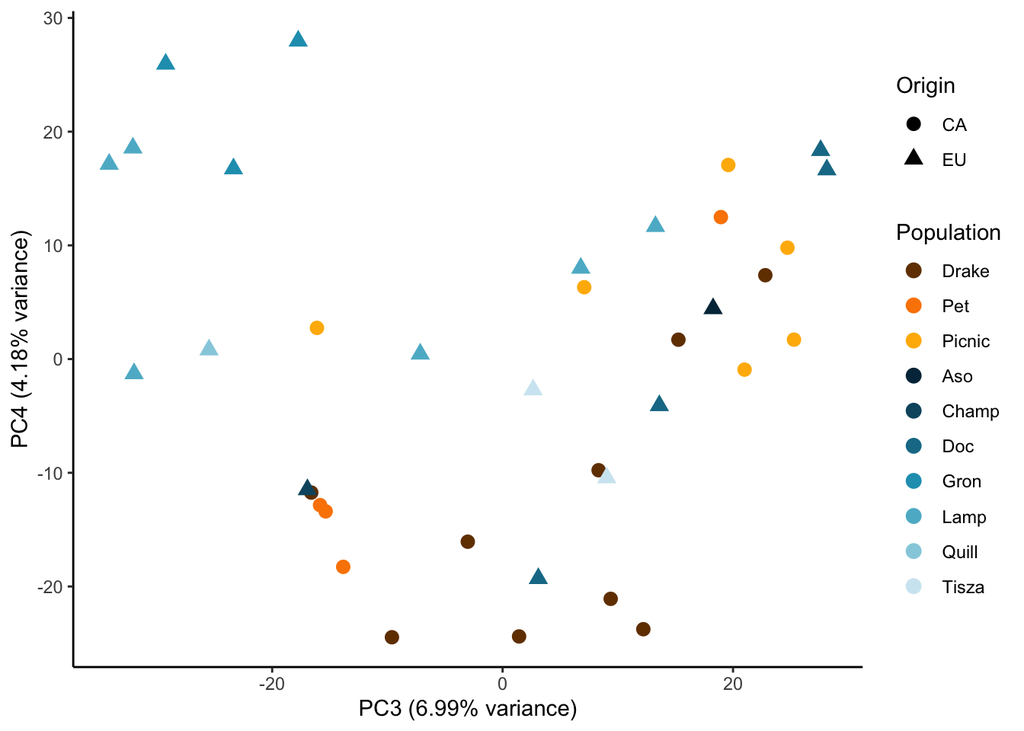

```r
ggsave("PCA_plot_pc12_population_origin.png",
       path = paste0(subDir,"/Plots/"),
       units="in",
       width = 6, height = 5)

ggplot(pcaData,aes(x=PC3, y=PC4, color = Population, shape = Origin)) +
  geom_point(size=3) +
  theme_classic() +
  scale_color_manual(values = genotype_colors) +
  xlab(paste0("PC3 (",pc3var,"% variance)")) +
  ylab(paste0("PC4 (",pc4var,"% variance)"))
```

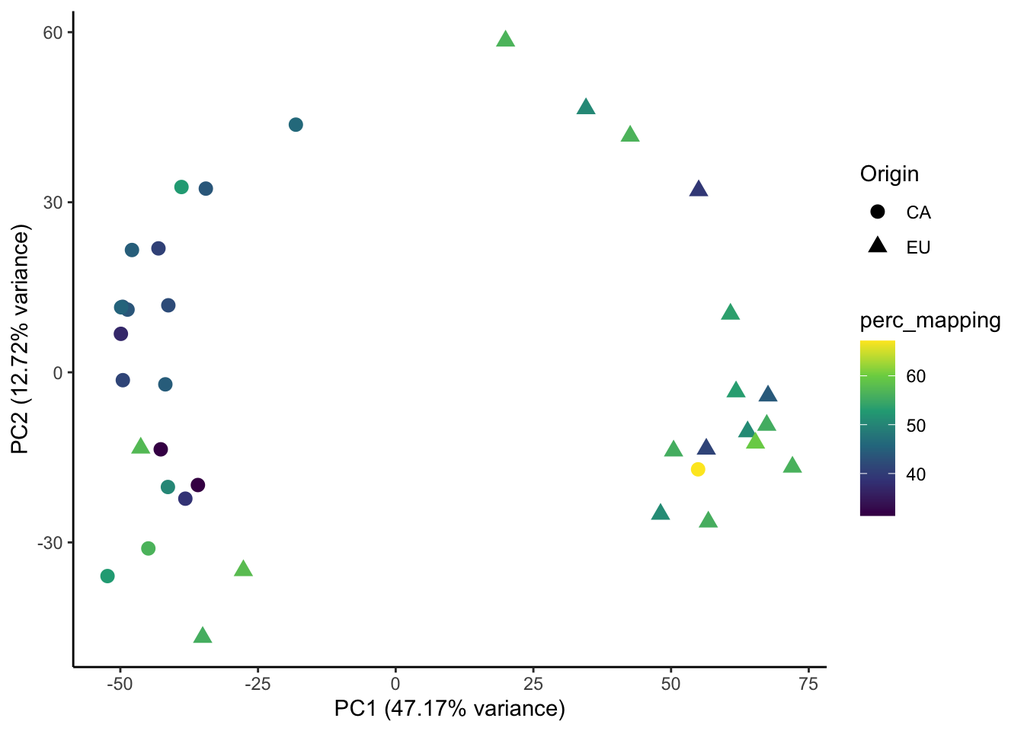

```r
ggsave("PCA_plot_pc34_population_origin.png",
       path = paste0(subDir,"/Plots/"),
       units="in",
       width = 6, height = 5)

## now plot PCA where color indicates mapping rate
ggplot(pcaData,aes(x=PC1, y=PC2, color = perc_mapping, shape = Origin)) +
  geom_point(size=3) +
  theme_classic() +
  scale_color_viridis_c() +
  #paletteer::scale_color_paletteer_c("viridis::plasma") +
  #scale_color_manual(values = genotype_colors) +
  xlab(paste0("PC1 (",pc1var,"% variance)")) +
  ylab(paste0("PC2 (",pc2var,"% variance)"))
```

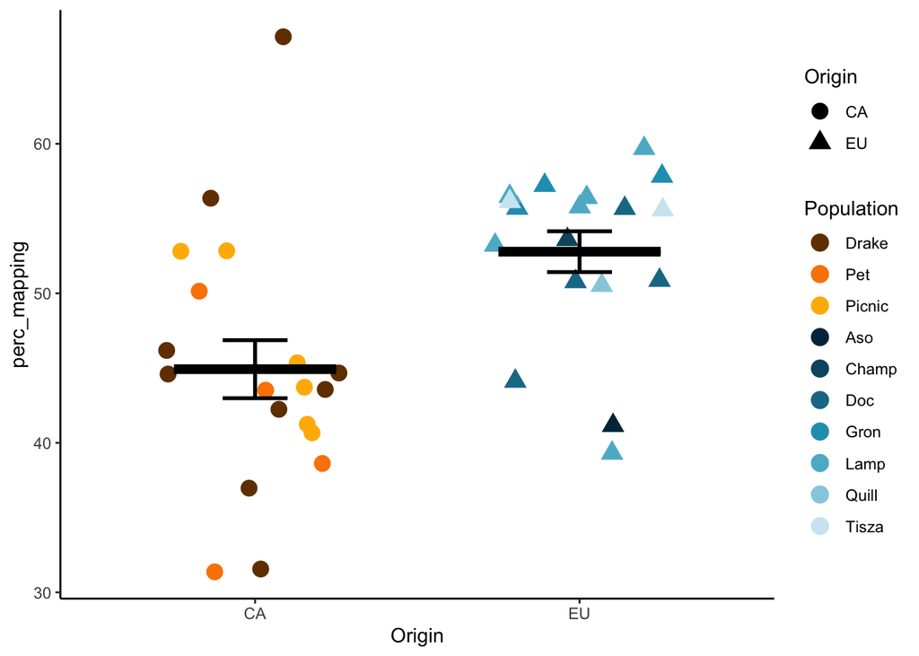

```r
ggsave("PCA_plot_pc12_percmapping_origin.png",
       path = paste0(subDir,"/Plots/"),
       units="in",
       width = 6, height = 5)

# plot mapping rates for both pops
ggplot(pcaData, aes(x=Origin,y=perc_mapping, color=Population,shape=Origin)) +
  geom_point(size = 4, position = position_jitter(w = 0.3, h = 0)) +
  # add mean line
  stat_summary(fun= mean, fun.min=mean, fun.max=mean, geom="crossbar", width=0.5, linewidth=1,color="black") +
  # add error bars
  stat_summary(fun.data=mean_se, fun.args = list(mult=1), geom="errorbar", width=0.2, linewidth=1,color="black") +
  scale_color_manual(values = genotype_colors) +
  theme_classic()
```

```r
# do a statistical test
# Perform t-test comparing perc_mapping values between EU and CA
t_test_result <- t.test(perc_mapping ~ Origin, data = pcaData)

# View t-test results
print(t_test_result)
```

```
##
##  Welch Two Sample t-test
##
## data:  perc_mapping by Origin
## t = -3.3114, df = 31.932, p-value = 0.002312
## alternative hypothesis: true difference in means between group CA and group EU is not equal to 0
## 95 percent confidence interval:
##  -12.691346  -3.023741
## sample estimates:
## mean in group CA mean in group EU
##         44.92579         52.78333
```

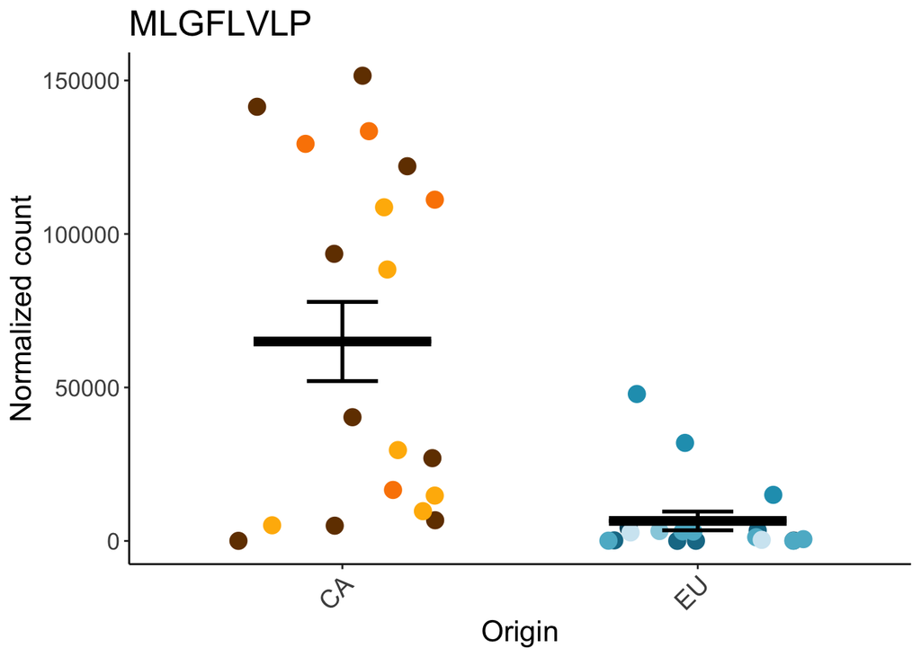

```r
ggsave("percmapping_origin_population.png",
       path = paste0(subDir,"/Plots/"),
       units="in",
       width = 4, height = 5)

# export pca data for separate graphing
write.csv(pcaData[,1:10],paste0(subDir,"/pca_data.csv"),row.names=FALSE)


# also plot norm counts for leaderless with population colored...
gene <- plotCounts(dds, gene = "MLGFLVLP", intgroup = "Origin", returnData = TRUE)

  # Define color palette for Origin
  gene$Origin <- factor(gene$Origin, levels = c("CA",
                                                    "EU"))
  gene$Population <- metadata$Population

  gene$Population <- factor(gene$Population, levels = c("Drake",
                                                            "Pet",
                                                            "Picnic",
                                                            "Aso",
                                                            "Champ",
                                                            "Doc",
                                                            "Gron",
                                                            "Lamp",
                                                            "Quill",
                                                            "Tisza"))
ggplot(data=gene,aes(x=Origin,y=count)) +
  geom_point(aes(colour = Population), size = 4, position = position_jitter(w = 0.3, h = 0)) +
  # add mean line
  stat_summary(fun= mean, fun.min=mean, fun.max=mean, geom="crossbar", width=0.5, linewidth=1,color="black") +
  # add error bars
  stat_summary(fun.data=mean_se, fun.args = list(mult=1), geom="errorbar", width=0.2, linewidth=1,color="black") +
  theme_classic()  +
  scale_color_manual(values = genotype_colors) +
  theme(legend.position = "none",
        text = element_text(size = 16),
        axis.text.x = element_text(angle = 45, hjust = 1, size = 14)) +
  ylab("Normalized count") +
  ggtitle("MLGFLVLP")
```

```r
  # save graph
  ggsave(paste0("MLGFLVLP","_pop_normalized_counts.png"),
         device="png",dpi="print",
         units = "in", width = 5, height = 3,
         path=paste0(subDir,"/NormCount-Graphs"))
```

## additional QC - Histogram of overall gene expression for EU vs CA

```r
# get norm counts for all genes
norm_counts <- counts(dds, normalized=TRUE)

# aggregate by origin (CA or EU)
# Step 1: Read metadata
#metadata <- readxl::read_xlsx(paste0(dir,"/metadata.xlsx"),sheet="metadata")

# Step 2: Make sure metadata and norm_counts align
all(colnames(norm_counts) %in% metadata$File_prefix)  # Should return TRUE
```

```
## [1] TRUE
```

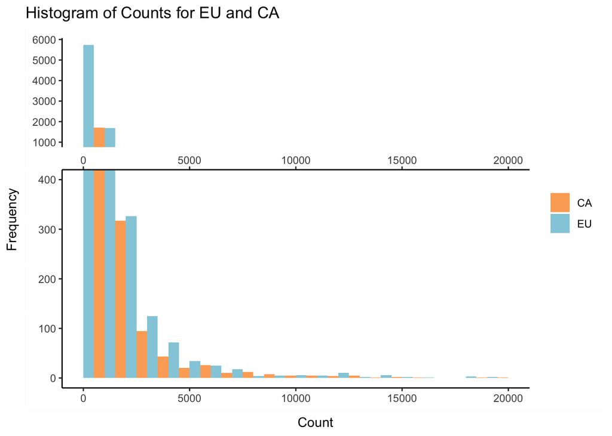

```r
# Step 3: Get Origin for each sample
origin_vector <- metadata$Origin[match(colnames(norm_counts), metadata$File_prefix)]

# Step 4: Aggregate norm_counts by Origin
library(dplyr)

# Transpose, bind Origin, then group and summarize
norm_counts_t <- as.data.frame(t(norm_counts))
norm_counts_t$Origin <- origin_vector

aggregated <- norm_counts_t %>%
  group_by(Origin) %>%
  summarise(across(.cols = where(is.numeric), .fns = mean))

# Step 5: Transpose back to original gene-by-sample format
norm_counts_by_origin <- as.data.frame(t(aggregated[,-1]))
colnames(norm_counts_by_origin) <- aggregated$Origin

# plot histogram
library(ggplot2)
library(ggbreak)
# Step 1: Reshape your data for plotting (long format)
norm_counts_long <- tidyr::pivot_longer(norm_counts_by_origin,
                                         cols = c(EU, CA),
                                         names_to = "Origin",
                                         values_to = "Count")

# Step 2: Plot histogram
ggplot(norm_counts_long, aes(x = Count, fill = Origin)) +
  geom_histogram(binwidth = 1000, alpha = 0.7, position = "dodge") +
  scale_fill_manual(values = c("EU" = '#5CB7CE', "CA" = '#fb8500')) +
  labs(title = "Histogram of Counts for EU and CA", x = "Count", y = "Frequency") +
  theme_classic() +
  theme(legend.title = element_blank()) + # Optional: Remove legend title
  xlim(0, 20000) +
  scale_y_break(c(400, 1000), scales = 0.5)  # breaks the y-axis between 200 and 19500
```

```r
# calculate rank sum p value
wilcox.test(Count ~ Origin, data = norm_counts_long, subset = Origin %in% c("CA", "EU"))
```

```
##
##  Wilcoxon rank sum test with continuity correction
##
## data:  Count by Origin
## W = 32549607, p-value = 0.4534
## alternative hypothesis: true location shift is not equal to 0
```

There is no significant difference in the relative amounts of gene expression between both EU and CA mushrooms.

# Plots for publication

## Extract DEseq2 results

The next bit of code will generate a new table from DESeq2 results, keeping only log2FC and padj for each genotype and comparison.

I saved it as a function to mini-fy each DESeq2 output table

group1 or group2 = comparison from deseq you want to make mini

```r
make_mini <- function(group1,group2,prefix="",keepmean=TRUE) {
  # group1 = "control"
  # group2 = "treatment"
  # prefix = "wildtype" # description you want used in your output minitable
  temp <- as.data.frame(results(dds,
                                contrast=c("Origin", group1, group2),
                                alpha=0.05,
                                , independentFiltering=FALSE, cooksCutoff=TRUE))
  temp$ID <- row.names(temp)

  output <- temp[,c("ID","baseMean","log2FoldChange","padj")]
  colnames(output) <- c("ID","baseMean",
                        paste0(prefix,"_L2FC"),
                        paste0(prefix,"_padj"))

  # if specified above, do not keep the baseMean column
  if(keepmean==FALSE) {
    output <- output[,c("ID",
                        paste0(prefix,"_L2FC"),
                        paste0(prefix,"_padj"))]
  }

  return(output)
}

deseq_results <- make_mini("CA","EU","EU_vs_CA")
deseq_results$ID <- gsub("^[^-]+-|\\.m01$", "", deseq_results$ID )

rmarkdown::paged_table(deseq_results[msdins$X4,], options = NULL)
```

|  | ID | baseMean | EU_vs_CA_L2FC | EU_vs_CA_padj |
| --- | --- | --- | --- | --- |
| NA | NA | NA | NA | NA |
| MLGFLVLP | MLGFLVLP | 36535.675733 | 3.31686642 | 0.0000022006430009844596697144 |
| NA.1 | NA | NA | NA | NA |
| AWLATCP_1 | AWLATCP_1 | 92.854224 | -0.40610347 | 0.4046918782477719189749620909 |
| NA.2 | NA | NA | NA | NA |
| LIQRPFAP_1 | LIQRPFAP_1 | 20.668640 | 0.49033914 | 0.0500381167695445397414211186 |
| LGRPESLP | LGRPESLP | 12.584763 | -1.99170674 | 0.0000020660466072784794207989 |
| LRLPPFMIPP | LRLPPFMIPP | 19.783357 | -1.67571124 | 0.0163291508128482094897027110 |
| IIGILLPP | IIGILLPP | 7.858281 | -3.84483686 | 0.0023820415569868742637626990 |
| AWLVDCP | AWLVDCP | 20.302731 | -1.30345978 | 0.0012478509968585629278520210 |

[output cut: 23 more lines]

## Heatmap

```r
# also make heatmap of genes with custom colors
genotype_colors <- c("#723D00","#fb8500","#ffb703",
                     "#023047","#0C556E","#177995","#219EBC","#5CB7CE","#96CFE0","#D1E8F2")

annotation_colors <- list(Population = setNames(genotype_colors, unique(df$Population)))

# Define your custom color scale (from dark blue to aqua)
my_colors <- colorRampPalette(c("grey90","#03045e"))(100)

# log transform count data
mat_log <- counts(dds, normalized=TRUE)[select,]
mat_log <- log10(mat_log)

top15 <- row.names(mat_log)
colnames(mat_log) <- metadata$Sample_ID

# remove the random prefix and suffixes
row.names(mat_log) <- gsub("^[^-]+-|\\.m01$", "", row.names(mat_log))
row.names(mat_log)
```

```
##  [1] "Ap.00g078360" "Ap.00g054880" "Ap.00g019870" "Ap.00g054640" "Ap.00g057760"
##  [6] "MLGFLVLP"     "Ap.00g068810" "Ap.00g039900" "SFFFPIP"      "Ap.00g008070"
## [11] "GPVFFA"       "Ap.00g078370" "Ap.00g011790" "Ap.00g001030" "Ap.00g063180"
```

```r
# remove log10(0) values that are -Inf
mat_log[mat_log == -Inf] <- 0

library(grid)
```

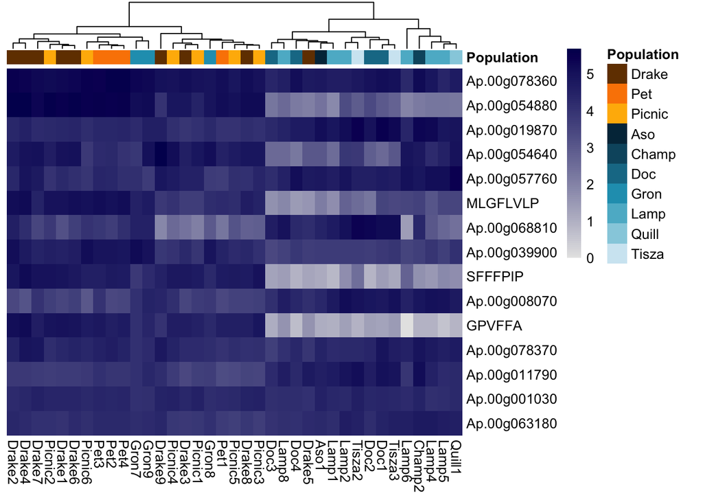

```r
heatmap_plot <- pheatmap(mat_log, cluster_rows=FALSE,
         show_rownames=TRUE,
         cluster_cols=TRUE,
         treeheight_col = 30,
         annotation_col=df,
         annotation_colors = annotation_colors,
         legend=TRUE,
         color=my_colors,
         legend_width = unit(0.2, "in"),
         legend_position = "right",
         border_color = "transparent")
```

```r
gtable_obj <- heatmap_plot$gtable

# Modify the legend's vertical position
# Find the legend in the gtable and move it up
gtable_obj$grobs[[which(gtable_obj$layout$name == "legend")]]$grobs[[1]]$gp <- gpar(fontsize = 20)  # Set the font size to 10


# Modify the y position of the annotation_colors legend
# Adjust the y-coordinate to move the legend up
annotation_legend_index <- which(gtable_obj$layout$name == "annotation_legend")
gtable_obj$grobs[[annotation_legend_index]]$grobs[[1]]$gp <- gpar(fontsize = 20)  # Set the font size to 10



# Draw the modified heatmap with legend moved up
pdf(paste0(subDir,"/Plots/heatmap.pdf"), width = 8, height = 5, family="ArialMT")  # Specify desired width and height

grid.draw(gtable_obj)
dev.off()
```

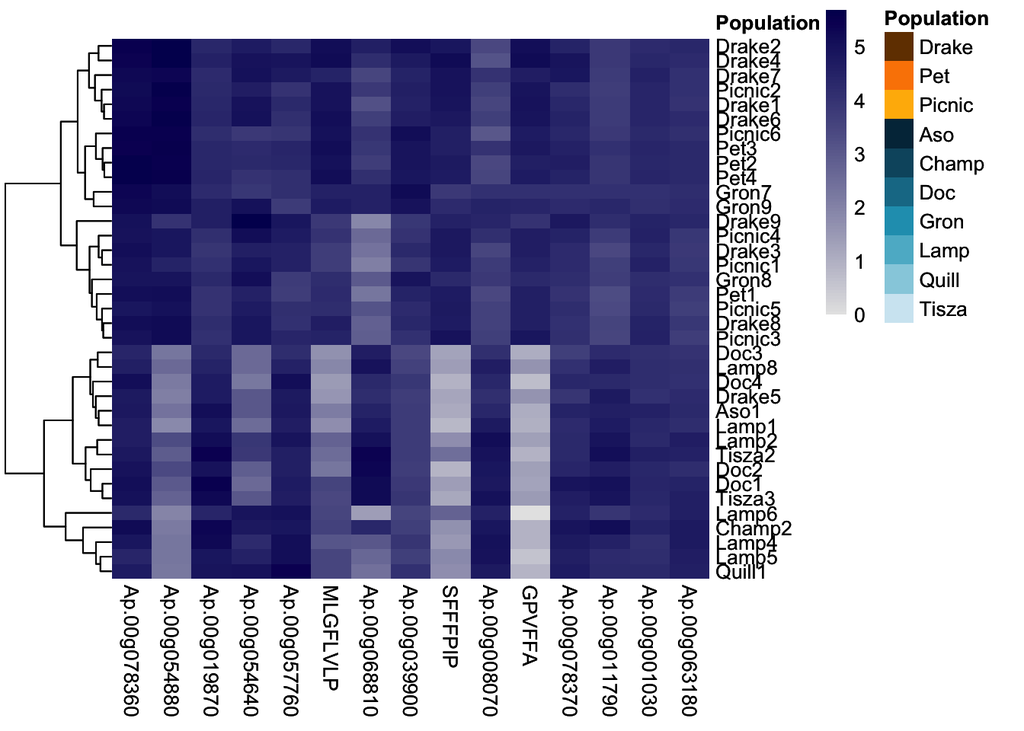

```r
# Transpose the matrix
mat_rotated <- t(mat_log)

pdf(paste0(subDir,"/Plots/heatmap_transposed.pdf"), width = 5, height = 8, family="ArialMT")  # Specify desired width and height

heatmap_plot<-pheatmap(mat_rotated, cluster_rows=TRUE,
         show_rownames=TRUE,
         cluster_cols=FALSE,
         treeheight_col = 30,
         annotation_col=df,
         annotation_colors = annotation_colors,
         legend=TRUE,
         color=my_colors,
         legend_width = unit(0.2, "in"),
         legend_position = "right",
         border_color = "transparent")
gtable_obj <- heatmap_plot$gtable
grid.draw(gtable_obj)
```

```r
dev.off()
```

## Supplemental figure: log10 counts for MSDINs

```r
######### FACET_WRAP log10 COUNTS
# extract variance stabilized gene count data for all msdin genes

# list of all msdins
list
```

```
##  [1] "MLGFLVLP"   "AWLATCP_1"  "LIQRPFAP_1" "LGRPESLP"   "LRLPPFMIPP"
##  [6] "IIGILLPP"   "AWLVDCP"    "IWGIGCNP"   "IWGIGCDP_1" "IWGIGCDP_2"
## [11] "IFLAFPIPP"  "IFWFIYFP"   "LIQRPFAP_2" "FNLFRFPYP"  "VQKPWSRP"
## [16] "IRLPPLFLPP" "FFFPPFFIPP" "FNILPFMLPP" "FFPIVFSPP"  "HFASFIPP"
## [21] "ISDPTAYP"   "LFFWFWFLWP" "SFFFPIP"    "FMPLAP"     "LILLAALGIP"
## [26] "GPVFFA"
```

```r
missing_genes <- setdiff(list, rownames(dds))
missing_genes
```

```
## character(0)
```

```r
list <- intersect(list, rownames(dds))


# generate facet_wrap for these samples

# extract data
mat2 <- as.data.frame(counts(dds,normalized=TRUE)[list,])
# log transform
mat2 <- log10(mat2)
# remove log10(0) values that are -Inf
mat2[mat2 == -Inf] <- 0
colnames(mat2) <- metadata$Sample_ID

# Reshape the data from wide to long format
library(tidyverse)
mat2_long <- mat2 %>%
  rownames_to_column("MSDIN") %>%        # Convert row names into a column
  pivot_longer(cols = -MSDIN,            # Pivot columns except for "Row"
               names_to = "Sample_ID",    # New column for column names
               values_to = "Value")    # New column for values

# add a new column to facet over:
# msdin type
msdin_type <- c("Known","Known SFFFPIP","Leaderless","Prolineless")
noncanonical <- c("MLGFLVLP","GPVFFA")

# Add the "Type" column
mat2_long$Type <- ifelse(mat2_long$MSDIN %in% noncanonical, "Noncanonical", "Known")
mat2_long$Type <- ifelse(mat2_long$MSDIN %in% "SFFFPIP", "Known SFFFPIP",mat2_long$Type)
mat2_long$Type <- ifelse(mat2_long$MSDIN %in% "MLGFLVLP", "Leaderless",mat2_long$Type)
mat2_long$Type <- ifelse(mat2_long$MSDIN %in% "GPVFFA", "Prolineless",mat2_long$Type)

# add additional metadata:
# Population
metadata2 <- metadata[,c("Sample_ID","Population","Origin")]
mat2_long <- mat2_long %>%
  left_join(metadata2, by = "Sample_ID")

# set order
mat2_long$Origin <- factor(mat2_long$Origin, levels = c("CA",
                                                    "EU"))

mat2_long$Population <- factor(mat2_long$Population, levels = c("Drake",
                                                            "Pet",
                                                            "Picnic",
                                                            "Aso",
                                                            "Champ",
                                                            "Doc",
                                                            "Gron",
                                                            "Lamp",
                                                            "Quill",
                                                            "Tisza"))

# extract p values for each MSDIN
deseq_msdin <- deseq_results[list,]

subset(deseq_msdin,EU_vs_CA_L2FC > 1 & EU_vs_CA_padj < 0.05)[,1]
```

```
## [1] "MLGFLVLP"   "IWGIGCDP_2" "LFFWFWFLWP" "SFFFPIP"    "LILLAALGIP"
## [6] "GPVFFA"
```

```r
subset(deseq_msdin,EU_vs_CA_L2FC < -1 & EU_vs_CA_padj < 0.05)[,1]
```

```
## [1] "LGRPESLP"   "LRLPPFMIPP" "IIGILLPP"   "AWLVDCP"    "FNLFRFPYP"
## [6] "ISDPTAYP"
```

```r
# round p values
options(scipen = 999)

deseq_msdin$EU_vs_CA_padj <- signif(deseq_msdin$EU_vs_CA_padj, 3)
deseq_msdin$EU_vs_CA_padj <- formatC(deseq_msdin$EU_vs_CA_padj, format = "g", digits = 3)

colnames(deseq_msdin)[1] <-"MSDIN"
# merge this onto mat2_long
mat2_long <- merge(mat2_long,deseq_msdin,by="MSDIN",all.x=TRUE)
mat2_long$EU_vs_CA_padj <- as.numeric(mat2_long$EU_vs_CA_padj)

# now plot it and facet by MSDIN
pdf(paste0(subDir,"/Plots/log10_msdin.pdf"), width = 12, height = 12, family="ArialMT")  # Specify desired width and height

ggplot(data=mat2_long,aes(x=Origin,y=Value)) +
  geom_point(aes(colour = Population), size = 4, position = position_jitter(w = 0.3, h = 0)) +
  # add mean line
  stat_summary(fun= mean, fun.min=mean, fun.max=mean, geom="crossbar", width=0.5, linewidth=1,color="black") +
  # add error bars
  stat_summary(fun.data=mean_se, fun.args = list(mult=1), geom="errorbar", width=0.2, linewidth=1,color="black") +
  theme_classic()  +
  scale_color_manual(values = genotype_colors) +
  theme(legend.position = "none",
        text = element_text(size = 16),
        axis.text.x = element_text(angle = 45, hjust = 1, size = 10)) +
  ylab("Log10(normalized count)") +
  facet_wrap(Type~MSDIN)+
  # Add p-value labels on each facet
  geom_text(aes(x = 1.5, y = max(Value) * 0.9, label = sprintf("p = %.3f", EU_vs_CA_padj)), size = 5, color = "black", inherit.aes = FALSE)

dev.off()
```

## Another version; Normalized counts for each MSDIN

```r
# also do this with normalized counts
# extract data
mat3 <- as.data.frame(counts[list,])
colnames(mat3) <- metadata$Sample_ID

# Reshape the data from wide to long format
mat3_long <- mat3 %>%
  rownames_to_column("MSDIN") %>%        # Convert row names into a column
  pivot_longer(cols = -MSDIN,            # Pivot columns except for "Row"
               names_to = "Sample_ID",    # New column for column names
               values_to = "Value")    # New column for values

# add a new column to facet over:
# msdin type
msdin_type <- c("canonical","new","leaderless","prolineless")
noncanonical <- c("MLGFLVLP","GPVFFA")

# Add the "Type" column
mat3_long$Type <- ifelse(mat3_long$MSDIN %in% noncanonical, "noncanonical", "canonical")
mat3_long$Type <- ifelse(mat3_long$MSDIN %in% "SFFFPIP", "new",mat3_long$Type)
mat3_long$Type <- ifelse(mat3_long$MSDIN %in% "MLGFLVLP", "leaderless",mat3_long$Type)
mat3_long$Type <- ifelse(mat3_long$MSDIN %in% "GPVFFA", "prolineless",mat3_long$Type)

# add additional metadata:
# Population
metadata2 <- metadata[,c("Sample_ID","Population","Origin")]
mat3_long <- mat3_long %>%
  left_join(metadata2, by = "Sample_ID")

# set order
mat3_long$Origin <- factor(mat3_long$Origin, levels = c("CA",
                                                    "EU"))

mat3_long$Population <- factor(mat3_long$Population, levels = c("Drake",
                                                            "Pet",
                                                            "Picnic",
                                                            "Aso",
                                                            "Champ",
                                                            "Doc",
                                                            "Gron",
                                                            "Lamp",
                                                            "Quill",
                                                            "Tisza"))



# now plot it and facet by MSDIN
pdf(paste0(subDir,"/Plots/normcount_msdin.pdf"), width = 12, height = 12, family="ArialMT")  # Specify desired width and height

ggplot(data=mat3_long,aes(x=Origin,y=Value)) +
  geom_point(aes(colour = Population), size = 4, position = position_jitter(w = 0.3, h = 0)) +
  # add mean line
  stat_summary(fun= mean, fun.min=mean, fun.max=mean, geom="crossbar", width=0.5, linewidth=1,color="black") +
  # add error bars
  stat_summary(fun.data=mean_se, fun.args = list(mult=1), geom="errorbar", width=0.2, linewidth=1,color="black") +
  theme_classic()  +
  scale_color_manual(values = genotype_colors) +
  theme(legend.position = "none",
        text = element_text(size = 16),
        strip.background = element_blank(),
        strip.text = element_text(face = "bold"),
        axis.text.x = element_text(angle = 45, hjust = 1, size = 10)) +
  ylab("Normalized count") +
  facet_wrap(~MSDIN, scales = "free_y")

dev.off()
```

## Violin plots and statistical tests

```r
# adjust type names for the graph
mat4_long<- mat2_long %>%
  mutate(Type = recode(Type,
                       "Known" = "Known MSDINs",
                       "Known SFFFPIP" = "Known SFFFPIP",
                       "Prolineless" = "Prolineless GPVFFA",
                       "Leaderless" = "Leaderless MLGFLVLP"))

genotype_colors <- c("#723D00","#fb8500","#ffb703",
                     "#023047","#0C556E","#177995","#219EBC","#5CB7CE","#96CFE0","#D1E8F2")


# set order
mat4_long$Type <- factor(mat4_long$Type, levels = c("Known MSDINs",
                                                    "Known SFFFPIP",
                                                    "Leaderless MLGFLVLP",
                                                    "Prolineless GPVFFA"))

pdf(paste0(subDir,"/Plots/violin.pdf"), width = 4.5, height = 2.5, family="ArialMT")

ggplot(data=mat4_long,aes(x=Origin,y=Value,fill=Origin)) +
geom_violin(trim = FALSE, adjust = 0.6, draw_quantiles = c(0.25, 0.75), linetype = "dashed") +
  geom_violin(trim = FALSE, adjust = 0.6, draw_quantiles = 0.5, fill="transparent") +
  theme_classic()  +
  scale_fill_manual(values = c("#fb8500", "#0C556E")) +
  ylab("Log10(normalized count)") +
    coord_cartesian(ylim = c(-0.5, 7)) +
  #geom_hline(yintercept = 0, color = "black", linetype = "solid", size = 1) +  # Black line at y=0
  facet_wrap(~Type, ncol=4) +
  theme(panel.spacing = unit(0, "lines"),
        strip.background = element_blank(),
        strip.text = element_text(face = "bold"),
        legend.position = "none",
        text = element_text(color = "black",size = 10))

dev.off()
```

```r
##### determine if normal distribution

# Group-wise Shapiro-Wilk test
normality_tests <- mat4_long %>%
  group_by(Origin, Type) %>%
  summarize(
    n = n(),
    mean = mean(Value, na.rm = TRUE),
    sem = sd(Value, na.rm = TRUE) / sqrt(n),
    shapiro_p = shapiro.test(Value)$p.value,
    is_normal = shapiro_p > 0.05
  )
print(normality_tests)
```

```
## # A tibble: 8 × 7
## # Groups:   Origin [2]
##   Origin Type                    n  mean    sem shapiro_p is_normal
##   <fct>  <fct>               <int> <dbl>  <dbl>     <dbl> <lgl>
## 1 CA     Known MSDINs          437  1.14 0.0349  6.94e-10 FALSE
## 2 CA     Known SFFFPIP          19  4.60 0.191   1.37e- 7 FALSE
## 3 CA     Leaderless MLGFLVLP    19  4.44 0.201   3.96e- 4 FALSE
## 4 CA     Prolineless GPVFFA     19  4.55 0.173   1.23e- 6 FALSE
## 5 EU     Known MSDINs          414  1.18 0.0347  1.16e- 9 FALSE
## 6 EU     Known SFFFPIP          18  1.95 0.264   2.63e- 3 FALSE
## 7 EU     Leaderless MLGFLVLP    18  3.00 0.233   3.66e- 1 TRUE
## 8 EU     Prolineless GPVFFA     18  1.54 0.306   1.56e- 4 FALSE
```

```r
#### also plot known and new/noncanonical separately
sub_canon <- subset(mat4_long,Type=="Known MSDINs")
pdf(paste0(subDir,"/Plots/violin_canon.pdf"), width = 1.5, height = 2.5, family="ArialMT")

ggplot(data=sub_canon,aes(x=Origin,y=Value,fill=Origin)) +
geom_violin(trim = FALSE, adjust = 0.6, draw_quantiles = c(0.25, 0.75), linetype = "dashed") +
  geom_violin(trim = FALSE, adjust = 0.6, draw_quantiles = 0.5, fill="transparent") +
  theme_classic()  +
  scale_fill_manual(values = c("#fb8500", "#0C556E")) +
  ylab("Log10(normalized count)") +
    coord_cartesian(ylim = c(-0.5, 7)) +
  #geom_hline(yintercept = 0, color = "black", linetype = "solid", size = 1) +  # Black line at y=0
  facet_wrap(~Type, ncol=4) +
  theme(panel.spacing = unit(0, "lines"),
        strip.background = element_blank(),
        strip.text = element_text(face = "bold"),
        legend.position = "none",
        text = element_text(color = "black",size = 10))

dev.off()
```

```r
sub_noncanon <- subset(mat4_long,Type!="Known MSDINs")
pdf(paste0(subDir,"/Plots/violin_noncanon.pdf"), width = 3.5, height = 2.5, family="ArialMT")

ggplot(data=sub_noncanon,aes(x=Origin,y=Value,fill=Origin)) +
  geom_violin(trim = FALSE, adjust = 0.6, draw_quantiles = c(0.25, 0.75), linetype = "dashed") +
  geom_violin(trim = FALSE, adjust = 0.6, draw_quantiles = 0.5, fill="transparent") +
  theme_classic()  +
  scale_fill_manual(values = c("#fb8500", "#0C556E")) +
  ylab("Log10(normalized count)") +
  coord_cartesian(ylim = c(-0.5, 7)) +
  #geom_hline(yintercept = 0, color = "black", linetype = "solid", size = 1) +  # Black line at y=0
  facet_wrap(~Type, ncol=4) +
  theme(panel.spacing = unit(0, "lines"),
        strip.background = element_blank(),
        strip.text = element_text(face = "bold"),
        legend.position = "none",
        text = element_text(color = "black",size = 10))

dev.off()
```

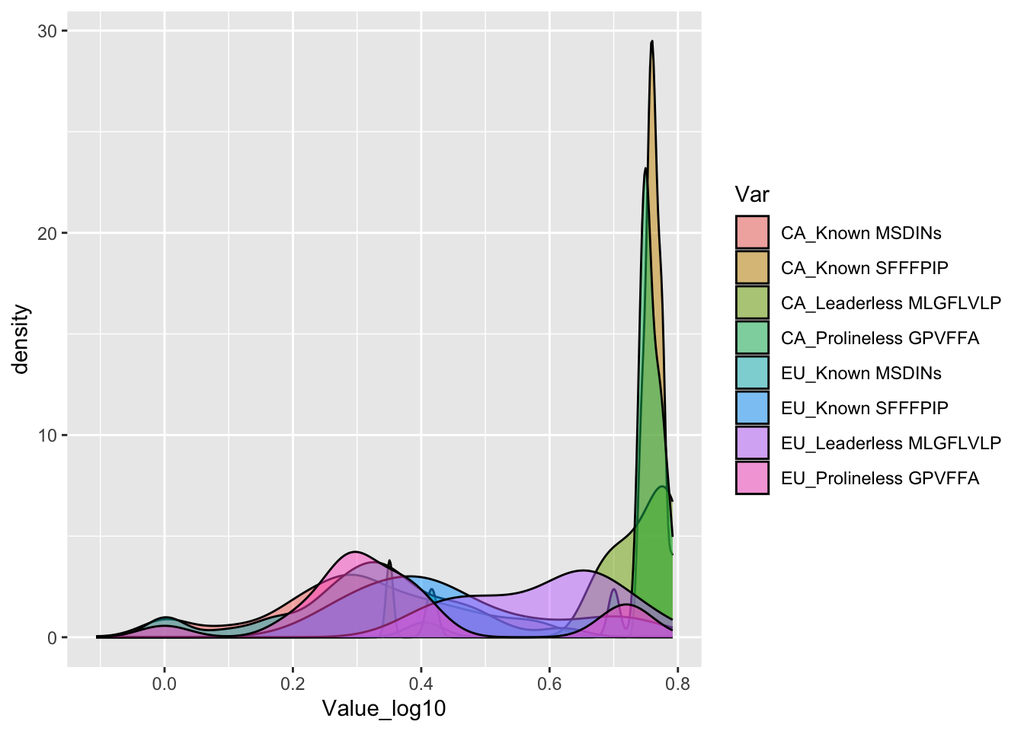

```r
library(dplyr)

# Run ANOVA for each Type
mat4_long$Var <- paste0(mat4_long$Origin,"_",mat4_long$Type)
# get log10:
# apply pseudocount for zeros
mat4_long$Value_log10 <- log10(mat4_long$Value +1)
df <- mat4_long[,c("Var","Value_log10")]

# make a plot of values
df$Var<-as.factor(df$Var)

df%>%ggplot(aes(x=Value_log10, fill=Var))+geom_density(alpha=0.5)
```

```r
# anova
model1<-lm(Value_log10~Var, data=df)
anova(model1)
```

```
## Analysis of Variance Table
##
## Response: Value_log10
##            Df Sum Sq Mean Sq F value                Pr(>F)
## Var         7 11.036 1.57662  74.285 < 0.00000000000000022 ***
## Residuals 954 20.248 0.02122
## ---
## Signif. codes:  0 '***' 0.001 '**' 0.01 '*' 0.05 '.' 0.1 ' ' 1
```

```r
# Print results
# Tukey multiple comparisons
library(multcomp)
anova_results<-summary(glht(model1, mcp(Var="Tukey")))
anova_results
```

```
##
##   Simultaneous Tests for General Linear Hypotheses
##
## Multiple Comparisons of Means: Tukey Contrasts
##
##
## Fit: lm(formula = Value_log10 ~ Var, data = df)
##
## Linear Hypotheses:
##                                                       Estimate Std. Error
## CA_Known SFFFPIP - CA_Known MSDINs == 0               0.436471   0.034141
## CA_Leaderless MLGFLVLP - CA_Known MSDINs == 0         0.424007   0.034141
## CA_Prolineless GPVFFA - CA_Known MSDINs == 0          0.434134   0.034141
## EU_Known MSDINs - CA_Known MSDINs == 0                0.011693   0.009992
## EU_Known SFFFPIP - CA_Known MSDINs == 0               0.140664   0.035038
## EU_Leaderless MLGFLVLP - CA_Known MSDINs == 0         0.284605   0.035038
## EU_Prolineless GPVFFA - CA_Known MSDINs == 0          0.058656   0.035038
## CA_Leaderless MLGFLVLP - CA_Known SFFFPIP == 0       -0.012465   0.047266
## CA_Prolineless GPVFFA - CA_Known SFFFPIP == 0        -0.002337   0.047266
## EU_Known MSDINs - CA_Known SFFFPIP == 0              -0.424779   0.034181
## EU_Known SFFFPIP - CA_Known SFFFPIP == 0             -0.295808   0.047918
## EU_Leaderless MLGFLVLP - CA_Known SFFFPIP == 0       -0.151867   0.047918
## EU_Prolineless GPVFFA - CA_Known SFFFPIP == 0        -0.377815   0.047918
## CA_Prolineless GPVFFA - CA_Leaderless MLGFLVLP == 0   0.010127   0.047266
## EU_Known MSDINs - CA_Leaderless MLGFLVLP == 0        -0.412314   0.034181
## EU_Known SFFFPIP - CA_Leaderless MLGFLVLP == 0       -0.283343   0.047918
## EU_Leaderless MLGFLVLP - CA_Leaderless MLGFLVLP == 0 -0.139402   0.047918
## EU_Prolineless GPVFFA - CA_Leaderless MLGFLVLP == 0  -0.365351   0.047918
## EU_Known MSDINs - CA_Prolineless GPVFFA == 0         -0.422442   0.034181
## EU_Known SFFFPIP - CA_Prolineless GPVFFA == 0        -0.293471   0.047918
## EU_Leaderless MLGFLVLP - CA_Prolineless GPVFFA == 0  -0.149529   0.047918
## EU_Prolineless GPVFFA - CA_Prolineless GPVFFA == 0   -0.375478   0.047918
## EU_Known SFFFPIP - EU_Known MSDINs == 0               0.128971   0.035077
## EU_Leaderless MLGFLVLP - EU_Known MSDINs == 0         0.272912   0.035077
## EU_Prolineless GPVFFA - EU_Known MSDINs == 0          0.046964   0.035077
## EU_Leaderless MLGFLVLP - EU_Known SFFFPIP == 0        0.143941   0.048561
## EU_Prolineless GPVFFA - EU_Known SFFFPIP == 0        -0.082007   0.048561
## EU_Prolineless GPVFFA - EU_Leaderless MLGFLVLP == 0  -0.225949   0.048561
##                                                      t value Pr(>|t|)
## CA_Known SFFFPIP - CA_Known MSDINs == 0               12.784  < 0.001 ***
```

[output cut: 15 more lines]

```
## EU_Leaderless MLGFLVLP - CA_Leaderless MLGFLVLP == 0  -2.909  0.06046 .
## EU_Prolineless GPVFFA - CA_Leaderless MLGFLVLP == 0   -7.624  < 0.001 ***
## EU_Known MSDINs - CA_Prolineless GPVFFA == 0         -12.359  < 0.001 ***
## EU_Known SFFFPIP - CA_Prolineless GPVFFA == 0         -6.124  < 0.001 ***
## EU_Leaderless MLGFLVLP - CA_Prolineless GPVFFA == 0   -3.121  0.03243 *
## EU_Prolineless GPVFFA - CA_Prolineless GPVFFA == 0    -7.836  < 0.001 ***
## EU_Known SFFFPIP - EU_Known MSDINs == 0                3.677  0.00506 **
## EU_Leaderless MLGFLVLP - EU_Known MSDINs == 0          7.780  < 0.001 ***
## EU_Prolineless GPVFFA - EU_Known MSDINs == 0           1.339  0.85818
## EU_Leaderless MLGFLVLP - EU_Known SFFFPIP == 0         2.964  0.05117 .
## EU_Prolineless GPVFFA - EU_Known SFFFPIP == 0         -1.689  0.65016
## EU_Prolineless GPVFFA - EU_Leaderless MLGFLVLP == 0   -4.653  < 0.001 ***
## ---
## Signif. codes:  0 '***' 0.001 '**' 0.01 '*' 0.05 '.' 0.1 ' ' 1
## (Adjusted p values reported -- single-step method)
```

```r
# Extract coefficients and p-values into a data frame
tukey_df <- as.data.frame(anova_results$test[c("coefficients", "sigma", "tstat", "pvalues")])

# Add row names as a column for pairwise comparison names
tukey_df$comparison <- rownames(tukey_df)
rownames(tukey_df) <- NULL

# Reorder columns to have comparison first
tukey_df <- tukey_df[, c("comparison", "coefficients", "sigma", "tstat", "pvalues")]
write.csv(tukey_df, paste0(subDir,"/violin_anova_results.csv"),row.names=FALSE)


# List of comparisons
comparisons <- list(
  c("CA_Leaderless MLGFLVLP", "CA_Known MSDINs"),
  c("CA_Prolineless GPVFFA", "CA_Known MSDINs"),
  c("CA_Known SFFFPIP", "CA_Known MSDINs"),

  c("EU_Known MSDINs", "CA_Known MSDINs"),
  c("EU_Known SFFFPIP", "CA_Known SFFFPIP"),
  c("EU_Leaderless MLGFLVLP", "CA_Leaderless MLGFLVLP"),
  c("EU_Prolineless GPVFFA", "CA_Prolineless GPVFFA"),

  c("EU_Leaderless MLGFLVLP", "EU_Known MSDINs"),
  c("EU_Prolineless GPVFFA", "EU_Known MSDINs"),
  c("EU_Known SFFFPIP", "EU_Known MSDINs"),

  c("EU_Prolineless GPVFFA", "EU_Leaderless MLGFLVLP")
)

# Function to run t-test
run_t_test <- function(group1, group2) {
  # Subset the data for each group
  group1_data <- df[df$Var == group1, "Value_log10"]
  group2_data <- df[df$Var == group2, "Value_log10"]

  # Perform t-test
  test_result <- t.test(group1_data, group2_data)

  # Return the result (comparison name, p-value, and test statistics)
  return(data.frame(
    Comparison = paste(group1, "vs", group2),
    p_value = test_result$p.value,
    statistic = test_result$statistic,
    conf_low = test_result$conf.int[1],
    conf_high = test_result$conf.int[2]
  ))
}

# Apply the function to all comparisons and combine the results
t_test_results <- do.call(rbind, lapply(comparisons, function(x) run_t_test(x[1], x[2])))

# Write the results to a CSV file
write.csv(t_test_results, paste0(subDir,"/violin_t_test_results.csv"), row.names = FALSE)

# Display the results
print(t_test_results)
```

```
##                                           Comparison                   p_value
## t          CA_Leaderless MLGFLVLP vs CA_Known MSDINs 0.00000000000000089643056
## t1          CA_Prolineless GPVFFA vs CA_Known MSDINs 0.00000000000000002401309
## t2               CA_Known SFFFPIP vs CA_Known MSDINs 0.00000000000000353749137
## t3                EU_Known MSDINs vs CA_Known MSDINs 0.24978689322915040293971
## t4              EU_Known SFFFPIP vs CA_Known SFFFPIP 0.00000006145031541353583
## t5  EU_Leaderless MLGFLVLP vs CA_Leaderless MLGFLVLP 0.00021149978053678548961
## t6    EU_Prolineless GPVFFA vs CA_Prolineless GPVFFA 0.00000006686394210939543
## t7         EU_Leaderless MLGFLVLP vs EU_Known MSDINs 0.00000000429768457139605
## t8          EU_Prolineless GPVFFA vs EU_Known MSDINs 0.30901525839360577396775
## t9               EU_Known SFFFPIP vs EU_Known MSDINs 0.00179213718340842913940
## t10  EU_Prolineless GPVFFA vs EU_Leaderless MLGFLVLP 0.00015310780722544751965
##     statistic    conf_low   conf_high
## t   19.623348  0.37928647  0.46872717
## t1  21.924323  0.39325862  0.47500956
## t2  18.965621  0.38876041  0.48418246
## t3   1.151656 -0.00823501  0.03162007
## t4  -7.218920 -0.37962891 -0.21198684
## t5  -4.172728 -0.20742178 -0.07138226
## t6  -7.827818 -0.47476350 -0.27619236
## t7   9.950150  0.21561505  0.33020948
## t8   1.047048 -0.04730971  0.14123696
## t9   3.644155  0.05475250  0.20318956
## t10 -4.379130 -0.33167715 -0.12022012
```

```r
# now do mann whitney u
run_mann_whitney <- function(group1, group2) {
  # Subset the data for each group
  group1_data <- df[df$Var == group1, "Value_log10"]
  group2_data <- df[df$Var == group2, "Value_log10"]

  # Perform Wilcoxon rank-sum test (Mann–Whitney U test)
  test_result <- wilcox.test(group1_data, group2_data, exact = FALSE)

  # Return the result (comparison name, p-value, and W statistic)
  return(data.frame(
    Comparison = paste(group1, "vs", group2),
    p_value = test_result$p.value,
    statistic = test_result$statistic
  ))
}

mann_whitney_results <- do.call(rbind, lapply(comparisons, function(comp) {
  run_mann_whitney(comp[1], comp[2])
}))
mann_whitney_results$p_value <- format(mann_whitney_results$p_value, scientific = TRUE)

print(mann_whitney_results)
```

```
##                                           Comparison      p_value statistic
## W          CA_Leaderless MLGFLVLP vs CA_Known MSDINs 6.535147e-13    8194.0
## W1          CA_Prolineless GPVFFA vs CA_Known MSDINs 5.887915e-13    8202.0
## W2               CA_Known SFFFPIP vs CA_Known MSDINs 1.305982e-12    8140.5
## W3                EU_Known MSDINs vs CA_Known MSDINs 1.048072e-01   96272.0
## W4              EU_Known SFFFPIP vs CA_Known SFFFPIP 1.701975e-06      13.0
## W5  EU_Leaderless MLGFLVLP vs CA_Leaderless MLGFLVLP 6.445666e-05      39.0
## W6    EU_Prolineless GPVFFA vs CA_Prolineless GPVFFA 5.773672e-07       6.0
## W7         EU_Leaderless MLGFLVLP vs EU_Known MSDINs 2.468038e-10    7008.0
## W8          EU_Prolineless GPVFFA vs EU_Known MSDINs 7.234004e-01    3910.0
## W9               EU_Known SFFFPIP vs EU_Known MSDINs 1.792991e-03    5345.5
## W10  EU_Prolineless GPVFFA vs EU_Leaderless MLGFLVLP 3.717844e-04      49.0
```

## Supplemental volcano plot

```r
group1 = "CA"
group2 = "EU"
gene_list = msdins$X4 # list of MSDINs
print(paste0(group1," vs ",group2))
```

```
## [1] "CA vs EU"
```

```r
res <- results(dds, contrast=c("Origin", group1, group2), alpha=0.05, independentFiltering=FALSE, cooksCutoff=TRUE)

# now save deseq results as a dataframe
deseqoutput <- as.data.frame(res)

# anything past -5 or 5 log2FoldChange, clip to -5 or 5 respectively
deseqoutput$log2FC_clip <- pmax(pmin(deseqoutput$log2FoldChange, 5), -5)

# also clip high pvals at 20
deseqoutput$padj_clip <- pmax(deseqoutput$padj, 0.00000000000000000001)

#c("#fb8500", "#5CB7CE")
# Create a custom color vector
keyvals <- ifelse(deseqoutput$log2FoldChange > 1 & deseqoutput$padj < 0.05, '#fb8500',
                  ifelse(deseqoutput$log2FoldChange < -1 & deseqoutput$padj < 0.05, '#5CB7CE', 'grey70'))

names(keyvals) <- rownames(deseqoutput)

deseqoutput$neglog10_padj <- -log10(deseqoutput$padj_clip)

label_data <- subset(deseqoutput, rownames(deseqoutput) %in% gene_list)

# plot it
library(ggplot2)

pdf(paste0(subDir,"/Plots/volcano.pdf"), width = 7, height = 5, family="ArialMT")  # Specify desired width and height

ggplot(deseqoutput, aes(x = log2FC_clip, y = neglog10_padj)) +
  geom_point(aes(color = keyvals), size = 2, alpha=0.5) +
  scale_color_identity() +  # uses the colors directly from keyvals
  geom_text_repel(data = label_data,
                  aes(label = rownames(label_data)),
                  size = 4,
                  max.overlaps = 10,
                  box.padding = 0.3,       # increase label box size
                  point.padding = 0.4,     # increase spacing between point and label
                  segment.color = 'grey50',
                  nudge_y = 0.5,           # move labels upward
                  force = 2) +                # stronger repulsion force
labs(
  #title = paste0(group1, " vs. ", group2),
  subtitle = "",  # italic("") is effectively blank
  caption = "",
  x = "Log2(Fold Change)",
  y = expression(-Log[10] ~ italic("Adj. P value"))
) +
  geom_point(data = label_data, color = "black", size = 2) +

  coord_cartesian(xlim = c(-5, 5), ylim = c(0, 20)) +
  scale_x_continuous(breaks = seq(-5, 5, 1)) +
  theme_classic() +
  theme(legend.position = "bottom")
dev.off()
```

```r
# ggsave(paste0(subDir,"/Plots/",group1,"_vs_",group2,"_pretty_volcano.png"),
#        units ="in",
#        width = 8,
#        height = 6)

summary(res)
```

```
##
## out of 8095 with nonzero total read count
## adjusted p-value < 0.1
## LFC > 0 (up)       : 2490, 31%
## LFC < 0 (down)     : 2842, 35%
## outliers [1]       : 0, 0%
## low counts [2]     : 0, 0%
## (mean count < 0)
## [1] see 'cooksCutoff' argument of ?results
## [2] see 'independentFiltering' argument of ?results
```

## Main principal component analysis figure (PCA)

```r
##### PCA PLOT

pdf(paste0(subDir,"/Plots/pca.pdf"), width = 4.5, height = 2.5, family="ArialMT")  # Specify desired width and height

ggplot(pcaData,aes(x=PC1, y=PC2, color = Population, shape=Origin)) +
  geom_point(size=3) +
  theme_classic() +
  scale_color_manual(values = genotype_colors) +
stat_ellipse(aes(group = Origin), colour = "black")+
  xlab(paste0("PC1 (",pc1var,"% variance)")) +
  ylab(paste0("PC2 (",pc2var,"% variance)")) +
  theme(panel.spacing = unit(0, "lines"),
        strip.background = element_blank(),
        text = element_text(color = "black",size = 10),
        legend.key.height = unit(0.15, 'in'))+
  guides(color = guide_legend(override.aes=list(shape = c(rep(16,3),rep(17,7)))))  # Customize shape of color legend


dev.off()
```

## MSDIN expression vs mapping rate

```r
# finally: also plot mapping rate for samples vs. counts for leaderless
dat <- read.csv(paste0(subDir,"/NormCount-Graphs/Data/MLGFLVLP.csv"))
colnames(dat)[1] <- "File_prefix"
# reread metadata
metadata <- read.csv(paste0(subDir,"/metadata_plus_mapping.csv"))

mini_meta <- metadata[,c("File_prefix","perc_mapping")]
mini_meta2 <- metadata[,c("Sample_ID","perc_mapping")]

# merge
dat2 <- merge(dat,mini_meta,by="File_prefix",all.x=TRUE)

dat2$Origin <- factor(dat2$Origin, levels = c("CA",
                                                    "EU"))

dat2$Population <- factor(dat2$Population, levels = c("Drake",
                                                            "Pet",
                                                            "Picnic",
                                                            "Aso",
                                                            "Champ",
                                                            "Doc",
                                                            "Gron",
                                                            "Lamp",
                                                            "Quill",
                                                            "Tisza"))


library(ggplot2)

# Fit the linear model
# for all points:
lm_model <- lm(count ~ perc_mapping, data = dat2)

# based on origin:
ca <- subset(dat2,Origin == "CA")
eu <- subset(dat2,Origin == "EU")

lm_model_ca <- lm(count ~ perc_mapping, data = ca)
lm_model_eu <- lm(count ~ perc_mapping, data = eu)

eqn_ca <- substitute(italic(y) == a + b %.% italic(x) * "," ~~ italic(R)^2 ~ "=" ~ r2,
                  list(a = as.numeric(format(coef(lm_model_ca)[1], digits = 3)),
                       b = as.numeric(format(coef(lm_model_ca)[2], digits = 3)),
                       r2 = format(summary(lm_model_ca)$r.squared, digits = 3)))

eqn_eu <- substitute(italic(y) == a + b %.% italic(x) * "," ~~ italic(R)^2 ~ "=" ~ r2,
                  list(a = as.numeric(format(coef(lm_model_eu)[1], digits = 3)),
                       b = as.numeric(format(coef(lm_model_eu)[2], digits = 3)),
                       r2 = format(summary(lm_model_eu)$r.squared, digits = 3)))

# Extract coefficients and R-squared
eqn <- substitute(italic(y) == a + b %.% italic(x) * "," ~~ italic(R)^2 ~ "=" ~ r2,
                  list(a = as.numeric(format(coef(lm_model)[1], digits = 3)),
                       b = as.numeric(format(coef(lm_model)[2], digits = 3)),
                       r2 = format(summary(lm_model)$r.squared, digits = 3)))
genotype_colors <- c("#723D00","#fb8500","#ffb703",
                     "#023047","#0C556E","#177995","#219EBC","#5CB7CE","#96CFE0","#D1E8F2")

ggplot(dat2, aes(x=perc_mapping,y=count,color=Population, shape=Origin)) +
  geom_point(size=3) +
  scale_color_manual(values = genotype_colors) +
  geom_smooth(method = "lm", se = FALSE, color = "black") +  # Add linear regression line
  annotate("text", x = min(dat2$perc_mapping), y = max(dat2$count),
           label = as.character(as.expression(eqn)), parse = TRUE, hjust = -0.3) +  # Add equation
  theme_classic()

ggsave("mapping_vs_leaderless_counts.png",
       path = paste0(subDir,"/Plots/"),
       units="in",
       width = 6, height = 5)

ggplot(dat2, aes(x=perc_mapping,y=count,color=Population, shape=Origin)) +
  geom_point(size=3) +
  scale_color_manual(values = genotype_colors) +
  geom_smooth(method = "lm", se = FALSE, color = "black") +  # Add linear regression line
  annotate("text", x = min(dat2$perc_mapping), y = max(dat2$count),
           label = as.character(as.expression(eqn_eu)), parse = TRUE, hjust = -0.3) +  # Add equation
  theme_classic()
ggsave("mapping_vs_leaderless_counts_EUlm.png",
       path = paste0(subDir,"/Plots/"),
       units="in",
       width = 6, height = 5)


ggplot(dat2, aes(x=perc_mapping,y=count,color=Population, shape=Origin)) +
  geom_point(size=3) +
  scale_color_manual(values = genotype_colors) +
  geom_smooth(method = "lm", se = FALSE, color = "black") +  # Add linear regression line
  annotate("text", x = min(dat2$perc_mapping), y = max(dat2$count),
           label = as.character(as.expression(eqn_ca)), parse = TRUE, hjust = -0.3) +  # Add equation
  theme_classic()

ggsave("mapping_vs_leaderless_counts_CAlm.png",
       path = paste0(subDir,"/Plots/"),
       units="in",
       width = 6, height = 5)
```

Write function to access counts for each msdin and plot expr vs. maturity

```r
# first plot maturity for CA vs EU samples
mini_meta <- metadata[,c("File_prefix","Sample_ID","Origin","Population","Maturity")]

# t test for maturity
group1 <- "CA"
group2 <- "EU"
group1_data <- mini_meta[mini_meta$Origin == group1, "Maturity"]
group2_data <- mini_meta[mini_meta$Origin == group2, "Maturity"]
mean(group1_data)
```

```
## [1] NA
```

```r
plotrix::std.error(group1_data)
```

```
##  Maturity
## 0.3845909
```

```r
mean(group2_data)
```

```
## [1] NA
```

```r
plotrix::std.error(group2_data)
```

```
##  Maturity
## 0.2914915
```

```r
# Perform t-test
test_result <- t.test(group1_data, group2_data)

  # Return the result (comparison name, p-value, and test statistics)
  data.frame(
    Comparison = paste(group1, "vs", group2),
    p_value = test_result$p.value,
    statistic = test_result$statistic,
    conf_low = test_result$conf.int[1],
    conf_high = test_result$conf.int[2]
  )
```

```
##   Comparison    p_value statistic  conf_low conf_high
## t   CA vs EU 0.09964065 -1.694132 -1.799273 0.1641848
```

```r
  # extract text for plot
  p_value = paste0("p = ",round(test_result$p.value,4))

mini_meta$Origin <- factor(mini_meta$Origin, levels = c("CA",
                                                "EU"))

mini_meta$Population <- factor(mini_meta$Population, levels = c("Drake",
                                                        "Pet",
                                                        "Picnic",
                                                        "Aso",
                                                        "Champ",
                                                        "Doc",
                                                        "Gron",
                                                        "Lamp",
                                                        "Quill",
                                                        "Tisza"))

genotype_colors <- c("#723D00","#fb8500","#ffb703",
                       "#023047","#0C556E","#177995","#219EBC","#5CB7CE","#96CFE0","#D1E8F2")


pdf(paste0(subDir,"/Plots/maturity.pdf"), width = 4, height = 4, family="ArialMT")

ggplot(mini_meta, aes(x=Origin,y=Maturity,color=Population)) +
  geom_point(aes(colour = Population), size = 4, position = position_jitter(w = 0.4, h = 0)) +
  scale_color_manual(values = genotype_colors) +
  # add mean line
  stat_summary(fun= mean, fun.min=mean, fun.max=mean, geom="crossbar", width=0.5, linewidth=1,color="black") +
  # add error bars
  stat_summary(fun.data=mean_se, fun.args = list(mult=1), geom="errorbar", width=0.2, linewidth=1,color="black") +
  annotate("text", x = "CA", y = 8,
           label = p_value, hjust = -0.3) +  # add p value
  coord_cartesian(ylim = c(0, 8)) +
  theme_classic()
dev.off()
```

## MSDIN expression vs maturity of mushroom

The maturity of each mushroom was scored prior to sampling:

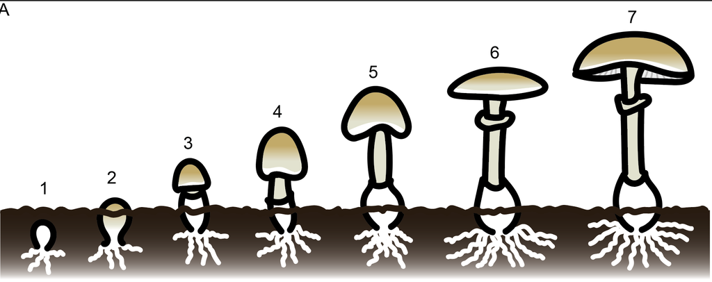

A. phalloides maturity

```r
plot_maturity <- function (msdin) {
  #msdin <- "MLGFLVLP"
  dat <- read.csv(paste0(subDir,"/NormCount-Graphs/Data/",msdin,".csv"))
  colnames(dat)[1] <- "File_prefix"
  mini_meta <- metadata[,c("File_prefix","Maturity")]
  mini_meta2 <- metadata[,c("Sample_ID","Maturity")]

  # merge
  dat2 <- merge(dat,mini_meta,by="File_prefix",all.x=TRUE)

  dat2$Origin <- factor(dat2$Origin, levels = c("CA",
                                                "EU"))

  dat2$Population <- factor(dat2$Population, levels = c("Drake",
                                                        "Pet",
                                                        "Picnic",
                                                        "Aso",
                                                        "Champ",
                                                        "Doc",
                                                        "Gron",
                                                        "Lamp",
                                                        "Quill",
                                                        "Tisza"))


  library(ggplot2)


  # Fit the linear model
  # for all points:
  lm_model <- lm(count ~ Maturity, data = dat2)

  # based on origin:
  ca <- subset(dat2,Origin == "CA")
  eu <- subset(dat2,Origin == "EU")

  # calculate p value with spearman ranked correlation
  corr_ca <- cor.test(x=ca$Maturity, y=ca$count, method = "kendall")
  corr_ca
  corr_ca2 <- corr_ca[["p.value"]]

  corr_eu <- cor.test(x=eu$Maturity, y=eu$count, method = "kendall")
  corr_eu2 <- corr_eu[["p.value"]]

  # do linear regression
  lm_model_ca <- lm(count ~ Maturity, data = ca)
  lm_model_eu <- lm(count ~ Maturity, data = eu)

  eqn_ca <- substitute(italic(y) == a + b %.% italic(x) * "," ~~ italic(R)^2 ~ "=" ~ r2,
                       list(a = as.numeric(format(coef(lm_model_ca)[1], digits = 3)),
                            b = as.numeric(format(coef(lm_model_ca)[2], digits = 3)),
                            r2 = format(summary(lm_model_ca)$r.squared, digits = 3)))

  eqn_eu <- substitute(italic(y) == a + b %.% italic(x) * "," ~~ italic(R)^2 ~ "=" ~ r2,
                       list(a = as.numeric(format(coef(lm_model_eu)[1], digits = 3)),
                            b = as.numeric(format(coef(lm_model_eu)[2], digits = 3)),
                            r2 = format(summary(lm_model_eu)$r.squared, digits = 3)))

  # Extract coefficients and R-squared
  eqn <- substitute(italic(y) == a + b %.% italic(x) * "," ~~ italic(R)^2 ~ "=" ~ r2,
                    list(a = as.numeric(format(coef(lm_model)[1], digits = 3)),
                         b = as.numeric(format(coef(lm_model)[2], digits = 3)),
                         r2 = format(summary(lm_model)$r.squared, digits = 3)))
  genotype_colors <- c("#723D00","#fb8500","#ffb703",
                       "#023047","#0C556E","#177995","#219EBC","#5CB7CE","#96CFE0","#D1E8F2")
  labeleqn <- paste(eqn_ca, eqn_eu, sep = "\n")

  ggplot(dat2, aes(x=Maturity,y=count,color=Population, shape=Origin)) +
    geom_point(size=3) +
    scale_color_manual(values = genotype_colors) +
    #geom_smooth(method = "lm", se = FALSE, color = "black") +  # Add linear regression line
    geom_smooth(
    data = subset(dat2, Origin == "CA"),
    method = "lm", se = FALSE, color = "#fb8500"
  ) +

  # One regression line for EU
  geom_smooth(
    data = subset(dat2, Origin == "EU"),
    method = "lm", se = FALSE, color = "#0C556E"
  ) +
      annotate("text",
           x = min(dat2$Maturity),
           y = max(dat2$count),
           label = as.character(as.expression(eqn_ca)),
           parse = TRUE,
           hjust = 0,
         color = "#fb8500") +
  annotate("text",
           x = min(dat2$Maturity),
           y = max(dat2$count) * 0.9,  # slightly lower
           label = as.character(as.expression(eqn_eu)),
           parse = TRUE,
           hjust = 0,
         color = "#0C556E") +
    theme_classic()

  ggsave(paste0("maturity_vs_",msdin,"_counts.png"),
         path = paste0(subDir,"/Plots/"),
         units="in",
         width = 5, height = 4)

  # also get values for each plot and return that
  ca <- c(a = as.numeric(format(coef(lm_model_ca)[1], digits = 3)),
                            b = as.numeric(format(coef(lm_model_ca)[2], digits = 3)),
                            r2 = format(summary(lm_model_ca)$r.squared, digits = 3))
  eu <- c(a = as.numeric(format(coef(lm_model_eu)[1], digits = 3)),
                            b = as.numeric(format(coef(lm_model_eu)[2], digits = 3)),
                            r2 = format(summary(lm_model_eu)$r.squared, digits = 3))
  output <- as.data.frame(rbind(ca,eu))
  output$MSDIN <- msdin
  output$Origin <- row.names(output)
  output$pval <- c(corr_ca2,corr_eu2)
  return(output)
}

# now run on each msdin and save the output
# make sure to only run on list of msdins
# MSDINs, leadered and leaderless:
list <- msdins$X4

# first see which of these genes have any counts at all
# get counts matrix for all genes
counts <- counts(dds, normalized=TRUE)
# find list of RiPPs also in count matrix
list <- intersect(list, rownames(counts))

results_df <- do.call(rbind, lapply(list, function(genename) {
  plot_maturity(msdin = genename)
}))
rmarkdown::paged_table(results_df, options = NULL)
```

|  | a | b | r2 | MSDIN | Origin | pval |
| --- | --- | --- | --- | --- | --- | --- |
| ca | -53934 | 26331 | 0.617 | MLGFLVLP | ca | 0.0004314902 |
| eu | 1905 | 865 | 0.00685 | MLGFLVLP | eu | 0.5576087627 |
| ca1 | 184 | -22.9 | 0.171 | AWLATCP_1 | ca | 0.3370504430 |
| eu1 | 261 | -28.9 | 0.124 | AWLATCP_1 | eu | 0.2911900393 |
| ca2 | 30.7 | -1.41 | 0.0524 | LIQRPFAP_1 | ca | 0.3370504430 |
| eu2 | 32.3 | -2.71 | 0.149 | LIQRPFAP_1 | eu | 0.0461794057 |
| ca3 | 1.7 | 0.852 | 0.0663 | LGRPESLP | ca | 0.1547241742 |
| eu3 | 31 | -1.86 | 0.0377 | LGRPESLP | eu | 0.4116714486 |
| ca4 | -1.17 | 2.46 | 0.109 | LRLPPFMIPP | ca | 0.0705364206 |
| eu4 | 4.41 | 5.02 | 0.0493 | LRLPPFMIPP | eu | 0.4565528101 |

[output cut: 42 more lines]

```r
write.csv(results_df,paste0(subDir,"/maturity_msdins.csv"))

###########
# also make nice leaderless plot
msdin <- "MLGFLVLP"
  dat <- read.csv(paste0(subDir,"/NormCount-Graphs/Data/",msdin,".csv"))
  colnames(dat)[1] <- "File_prefix"
  mini_meta <- metadata[,c("File_prefix","Maturity")]
  mini_meta2 <- metadata[,c("Sample_ID","Maturity")]

  # merge
  dat2 <- merge(dat,mini_meta,by="File_prefix",all.x=TRUE)

  dat2$Origin <- factor(dat2$Origin, levels = c("CA",
                                                "EU"))

  dat2$Population <- factor(dat2$Population, levels = c("Drake",
                                                        "Pet",
                                                        "Picnic",
                                                        "Aso",
                                                        "Champ",
                                                        "Doc",
                                                        "Gron",
                                                        "Lamp",
                                                        "Quill",
                                                        "Tisza"))


  library(ggplot2)

  # Fit the linear model
  # for all points:
  lm_model <- lm(count ~ Maturity, data = dat2)

  # based on origin:
  ca <- subset(dat2,Origin == "CA")
  eu <- subset(dat2,Origin == "EU")

  lm_model_ca <- lm(count ~ Maturity, data = ca)
  lm_model_eu <- lm(count ~ Maturity, data = eu)

  eqn_ca <- substitute(italic(y) == a + b %.% italic(x) * "," ~~ italic(R)^2 ~ "=" ~ r2,
                       list(a = as.numeric(format(coef(lm_model_ca)[1], digits = 3)),
                            b = as.numeric(format(coef(lm_model_ca)[2], digits = 3)),
                            r2 = format(summary(lm_model_ca)$r.squared, digits = 3)))

  eqn_eu <- substitute(italic(y) == a + b %.% italic(x) * "," ~~ italic(R)^2 ~ "=" ~ r2,
                       list(a = as.numeric(format(coef(lm_model_eu)[1], digits = 3)),
                            b = as.numeric(format(coef(lm_model_eu)[2], digits = 3)),
                            r2 = format(summary(lm_model_eu)$r.squared, digits = 3)))

  # Extract coefficients and R-squared
  eqn <- substitute(italic(y) == a + b %.% italic(x) * "," ~~ italic(R)^2 ~ "=" ~ r2,
                    list(a = as.numeric(format(coef(lm_model)[1], digits = 3)),
                         b = as.numeric(format(coef(lm_model)[2], digits = 3)),
                         r2 = format(summary(lm_model)$r.squared, digits = 3)))
  genotype_colors <- c("#723D00","#fb8500","#ffb703",
                       "#023047","#0C556E","#177995","#219EBC","#5CB7CE","#96CFE0","#D1E8F2")
  labeleqn <- paste(eqn_ca, eqn_eu, sep = "\n")


pdf(paste0(subDir,"/Plots/maturity_leaderless.pdf"), width = 5, height = 4, family="ArialMT")

  ggplot(dat2, aes(x=Maturity,y=count,color=Population, shape=Origin)) +
    geom_point(size=3) +
    scale_color_manual(values = genotype_colors) +
    #geom_smooth(method = "lm", se = FALSE, color = "black") +  # Add linear regression line
    geom_smooth(
    data = subset(dat2, Origin == "CA"),
    method = "lm", se = FALSE, color = "#fb8500"
  ) +

  # One regression line for EU
  geom_smooth(
    data = subset(dat2, Origin == "EU"),
    method = "lm", se = FALSE, color = "#0C556E"
  ) +
      annotate("text",
           x = min(dat2$Maturity),
           y = max(dat2$count),
           label = as.character(as.expression(eqn_ca)),
           parse = TRUE,
           hjust = 0,
         color = "#fb8500") +
  annotate("text",
           x = min(dat2$Maturity),
           y = max(dat2$count) * 0.9,  # slightly lower
           label = as.character(as.expression(eqn_eu)),
           parse = TRUE,
           hjust = 0,
         color = "#0C556E") +
    theme_classic()
  dev.off()
```

## PCA of MSDINs only

```r
# subset dds to only include msdins

# generate dds object
library(DESeq2)
setClassUnion("ExpData", c("matrix", "SummarizedExperiment"))
dds2 <- DESeqDataSetFromMatrix(countData = cts,
                              colData = coldata,
                              design = ~ Origin)
# keep only the msdins
list <- msdins$X4

# first see which of these genes have any counts at all
# Check which entries in 'list' are NOT in the rownames
missing <- setdiff(list, rownames(dds2))
missing
```

```
## character(0)
```

```r
valid_list <- intersect(list, rownames(dds2))
# this should be all msdins
valid_list
```

```
##  [1] "MYNPPYFLPP" "MLGFLVLP"   "MLPGMVAFS"  "AWLATCP_1"  "AWLATCP_2"
##  [6] "LIQRPFAP_1" "LGRPESLP"   "LRLPPFMIPP" "IIGILLPP"   "AWLVDCP"
## [11] "IWGIGCNP"   "IWGIGCDP_1" "IWGIGCDP_2" "TIYYLYFIP"  "IFLAFPIPP"
## [16] "IFWFIYFP"   "LIQRPFAP_2" "FNLFRFPYP"  "VQKPWSRP"   "IRLPPLFLPP"
## [21] "FFFPPFFIPP" "FNILPFMLPP" "FFPIVFSPP"  "HFASFIPP"   "ISDPTAYP"
## [26] "LFFWFWFLWP" "SFFFPIP"    "FMPLAP"     "LILLAALGIP" "GPVFFA"
## [31] "GVILIIP"    "FIFPPFFIPP" "LPILPIPPLP"
```

```r
dds2 <- dds2[valid_list, ]

dds2 <- DESeq(dds2)
```

```
## -- note: fitType='parametric', but the dispersion trend was not well captured by the
##    function: y = a/x + b, and a local regression fit was automatically substituted.
##    specify fitType='local' or 'mean' to avoid this message next time.
```

```
## -- replacing outliers and refitting for 2 genes
## -- DESeq argument 'minReplicatesForReplace' = 7
## -- original counts are preserved in counts(dds)
```

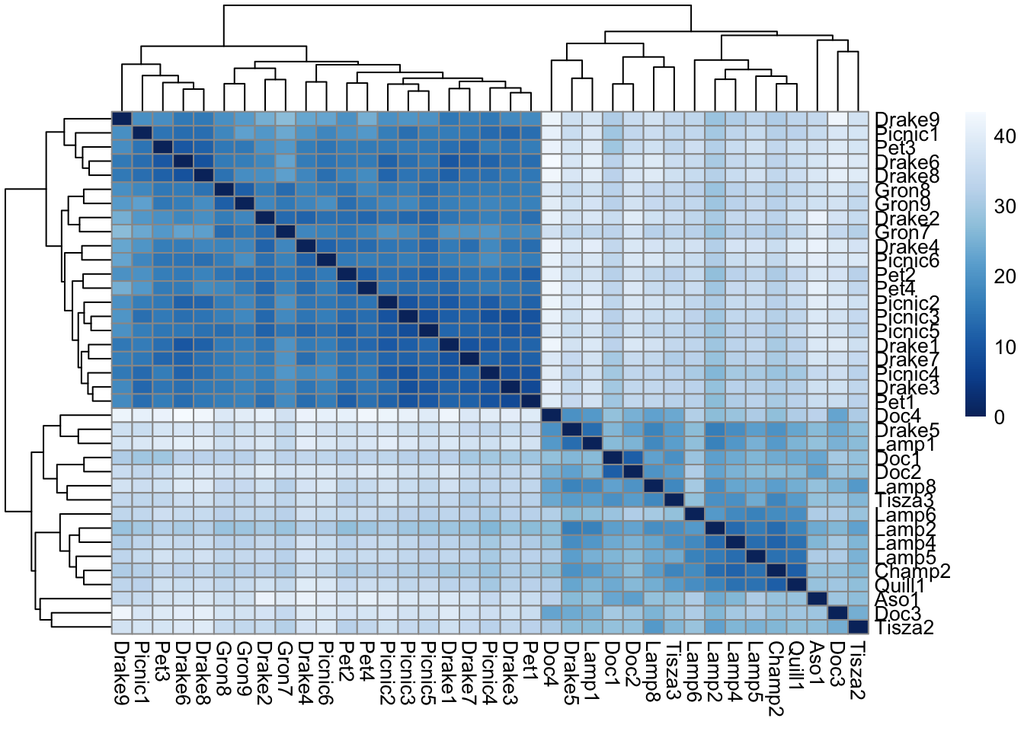

```r
vsd2 <- varianceStabilizingTransformation(dds2, blind=FALSE)

# find distances between samples
sampleDists <- dist(t(assay(vsd2)))

# reformat distances
sampleDistMatrix <- as.matrix(sampleDists)

# make new data frame with only Population stage info
#metadata <- readxl::read_xlsx(paste0(dir,"/metadata.xlsx"),sheet="metadata")

#metadata <- metadata[!metadata$Sample_ID %in% c("Pet1-redo","Pet5"),]

samples <- metadata$Sample_ID

# make row and column names the same as sample IDs
rownames(sampleDistMatrix) <- samples
colnames(sampleDistMatrix) <- samples

# generate some nice colors
library(RColorBrewer)
colors <- colorRampPalette( rev(brewer.pal(9, "Blues")) )(255)

# plot it
library(pheatmap)
pheatmap(sampleDistMatrix,
         clustering_distance_rows=sampleDists,
         clustering_distance_cols=sampleDists,
         col=colors)
```

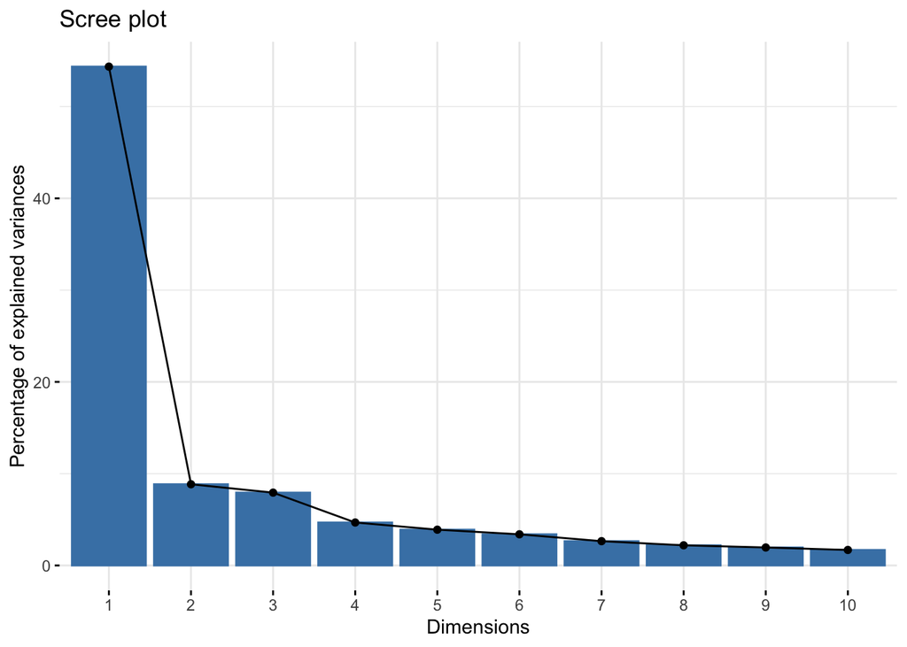

```r
# next lets generate a PCA plot on variance stabilized data
vsd_out <- assay(vsd2)

# run PCA analysis
pca <- prcomp(t(vsd_out))

# plot scree
library(factoextra)
fviz_eig(pca)
```

```r
# Create data frame with metadata and PC3 and PC4 values for input to ggplot
pcaData <- cbind(metadata[,c(2:5,8,13,15)], pca$x)

# Define color palette for genotypes
pcaData$Origin <- factor(pcaData$Origin, levels = c("CA",
                                                    "EU"))
# find percent variance for PC1 and PC2
# summary of variance
pcasummary <- summary(pca)
pcasummary
```

```
## Importance of components:
##                            PC1     PC2     PC3    PC4     PC5     PC6     PC7
## Standard deviation     14.8640 5.99708 5.67979 4.3618 3.98125 3.71512 3.27998
## Proportion of Variance  0.5435 0.08848 0.07936 0.0468 0.03899 0.03395 0.02647
## Cumulative Proportion   0.5435 0.63200 0.71137 0.7582 0.79716 0.83112 0.85758
##                            PC8     PC9    PC10    PC11    PC12    PC13    PC14
## Standard deviation     2.98778 2.82122 2.62042 2.24451 2.18749 1.92729 1.83987
## Proportion of Variance 0.02196 0.01958 0.01689 0.01239 0.01177 0.00914 0.00833
## Cumulative Proportion  0.87954 0.89912 0.91602 0.92841 0.94018 0.94932 0.95765
##                           PC15   PC16    PC17    PC18    PC19    PC20    PC21
## Standard deviation     1.78200 1.5997 1.42650 1.31553 1.19035 1.11217 1.08699
## Proportion of Variance 0.00781 0.0063 0.00501 0.00426 0.00349 0.00304 0.00291
## Cumulative Proportion  0.96546 0.9718 0.97676 0.98102 0.98450 0.98755 0.99045
##                           PC22   PC23    PC24    PC25    PC26   PC27    PC28
## Standard deviation     1.03047 0.8542 0.79616 0.65940 0.61565 0.4919 0.41226
## Proportion of Variance 0.00261 0.0018 0.00156 0.00107 0.00093 0.0006 0.00042
## Cumulative Proportion  0.99307 0.9949 0.99642 0.99749 0.99842 0.9990 0.99944
##                           PC29    PC30   PC31    PC32                 PC33
## Standard deviation     0.33936 0.26002 0.2005 0.07742 0.000000000000001112
## Proportion of Variance 0.00028 0.00017 0.0001 0.00001 0.000000000000000000
## Cumulative Proportion  0.99972 0.99989 1.0000 1.00000 1.000000000000000000
```

```r
pc1var <- round(pcasummary$importance[2],digits = 4) * 100
pc2var <- round(pcasummary$importance[5],digits = 4) * 100
pc3var <- round(pcasummary$importance[8],digits = 4) * 100
pc4var <- round(pcasummary$importance[11],digits = 4) * 100


pcaData$Population <- factor(pcaData$Population, levels = c("Drake",
                                                            "Pet",
                                                            "Picnic",
                                                            "Aso",
                                                            "Champ",
                                                            "Doc",
                                                            "Gron",
                                                            "Lamp",
                                                            "Quill",
                                                            "Tisza"))



pdf(paste0(subDir,"/Plots/pca_msdins_only.pdf"), width = 4.5, height = 2.5, family="ArialMT")  # Specify desired width and height

ggplot(pcaData,aes(x=PC1, y=PC2, color = Population, shape=Origin)) +
  geom_point(size=3) +
  theme_classic() +
  scale_color_manual(values = genotype_colors) +
stat_ellipse(aes(group = Origin), colour = "black")+
  xlab(paste0("PC1 (",pc1var,"% variance)")) +
  ylab(paste0("PC2 (",pc2var,"% variance)")) +
  theme(panel.spacing = unit(0, "lines"),
        strip.background = element_blank(),
        text = element_text(color = "black",size = 10),
        legend.key.height = unit(0.15, 'in'))+
  guides(color = guide_legend(override.aes=list(shape = c(rep(16,3),rep(17,7)))))  # Customize shape of color legend


dev.off()
```

## PCA of all non-MSDIN transcripts

```r
# subset dds to exclude msdins
# generate dds object
library(DESeq2)
dds2 <- DESeqDataSetFromMatrix(countData = cts,
                              colData = coldata,
                              design = ~ Origin)
# exclude the msdins
list <- msdins$X4

valid_list <- !rownames(dds2) %in% list
dds2 <- dds2[valid_list, ]

dds2 <- DESeq(dds2)
```

```
## -- replacing outliers and refitting for 112 genes
## -- DESeq argument 'minReplicatesForReplace' = 7
## -- original counts are preserved in counts(dds)
```

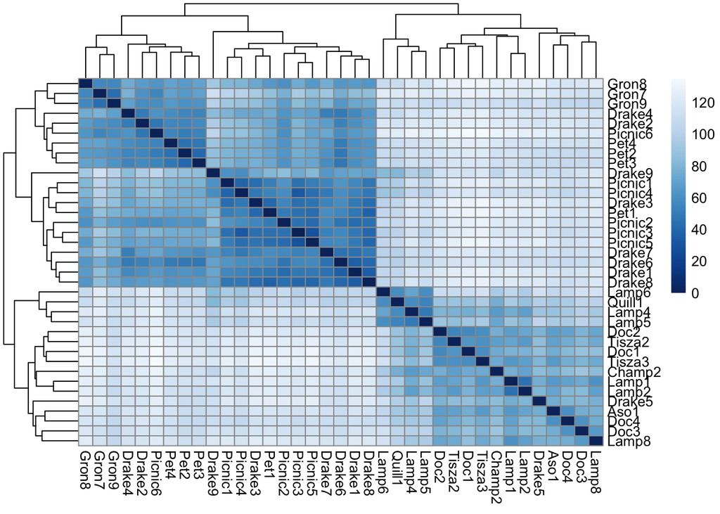

```r
vsd2 <- varianceStabilizingTransformation(dds2, blind=FALSE)

# find distances between samples
sampleDists <- dist(t(assay(vsd2)))

# reformat distances
sampleDistMatrix <- as.matrix(sampleDists)

# make new data frame with only Population stage info
df <- as.data.frame(colData(dds2)[,c("Population")])
colnames(df) <- c("Population")
#samples <- colnames(assay(ntd))
samples <- metadata$Sample_ID

# make row and column names the same as sample IDs
rownames(sampleDistMatrix) <- samples
colnames(sampleDistMatrix) <- samples

# generate some nice colors
library(RColorBrewer)
colors <- colorRampPalette( rev(brewer.pal(9, "Blues")) )(255)

# plot it
library(pheatmap)
pheatmap(sampleDistMatrix,
         clustering_distance_rows=sampleDists,
         clustering_distance_cols=sampleDists,
         col=colors)
```

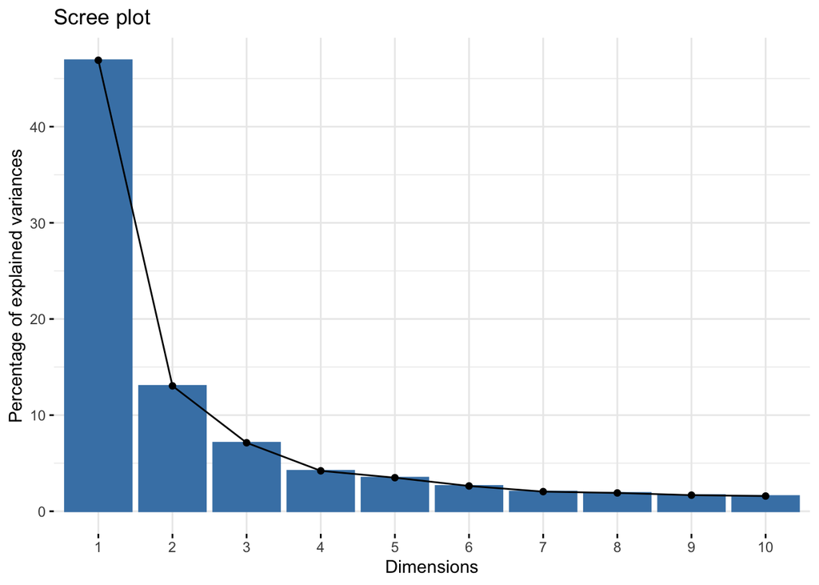

```r
# next lets generate a PCA plot on variance stabilized data
vsd_out <- assay(vsd2)

# run PCA analysis
pca <- prcomp(t(vsd_out))

# plot scree
library(factoextra)
fviz_eig(pca)
```

```r
# Create data frame with metadata and PC3 and PC4 values for input to ggplot
pcaData <- cbind(metadata[,c(2:5,8,13,15)], pca$x)

# Define color palette for genotypes
pcaData$Origin <- factor(pcaData$Origin, levels = c("CA",
                                                    "EU"))
# find percent variance for PC1 and PC2
# summary of variance
pcasummary <- summary(pca)
pcasummary
```

```
## Importance of components:
##                            PC1     PC2      PC3      PC4      PC5      PC6
## Standard deviation     47.3575 24.9699 18.45869 14.18347 12.92323 11.21752
## Proportion of Variance  0.4691  0.1304  0.07127  0.04208  0.03493  0.02632
## Cumulative Proportion   0.4691  0.5995  0.67081  0.71289  0.74783  0.77415
##                            PC7     PC8     PC9    PC10   PC11    PC12    PC13
## Standard deviation     9.88720 9.54770 8.95558 8.70501 7.8231 7.63303 7.24637
## Proportion of Variance 0.02045 0.01907 0.01678 0.01585 0.0128 0.01219 0.01098
## Cumulative Proportion  0.79459 0.81366 0.83044 0.84629 0.8591 0.87128 0.88226
##                           PC14    PC15    PC16    PC17   PC18   PC19    PC20
## Standard deviation     6.90728 6.67042 6.49784 6.08704 6.0258 5.7869 5.68652
## Proportion of Variance 0.00998 0.00931 0.00883 0.00775 0.0076 0.0070 0.00676
## Cumulative Proportion  0.89224 0.90155 0.91038 0.91813 0.9257 0.9327 0.93950
##                           PC21    PC22    PC23    PC24    PC25    PC26    PC27
## Standard deviation     5.59398 5.34926 5.28243 4.81172 4.72775 4.53029 4.36940
## Proportion of Variance 0.00655 0.00599 0.00584 0.00484 0.00468 0.00429 0.00399
## Cumulative Proportion  0.94604 0.95203 0.95786 0.96271 0.96738 0.97167 0.97567
##                           PC28    PC29    PC30    PC31    PC32    PC33    PC34
## Standard deviation     4.27551 4.15915 3.99409 3.80822 3.76587 3.41928 3.17808
## Proportion of Variance 0.00382 0.00362 0.00334 0.00303 0.00297 0.00245 0.00211
## Cumulative Proportion  0.97949 0.98311 0.98645 0.98948 0.99245 0.99489 0.99701
##                           PC35    PC36                PC37
## Standard deviation     2.77734 2.56994 0.00000000000004139
## Proportion of Variance 0.00161 0.00138 0.00000000000000000
## Cumulative Proportion  0.99862 1.00000 1.00000000000000000
```

```r
pc1var <- round(pcasummary$importance[2],digits = 4) * 100
pc2var <- round(pcasummary$importance[5],digits = 4) * 100
pc3var <- round(pcasummary$importance[8],digits = 4) * 100
pc4var <- round(pcasummary$importance[11],digits = 4) * 100


pcaData$Population <- factor(pcaData$Population, levels = c("Drake",
                                                            "Pet",
                                                            "Picnic",
                                                            "Aso",
                                                            "Champ",
                                                            "Doc",
                                                            "Gron",
                                                            "Lamp",
                                                            "Quill",
                                                            "Tisza"))



pdf(paste0(subDir,"/Plots/pca_no_msdins.pdf"), width = 4.5, height = 2.5, family="ArialMT")  # Specify desired width and height

ggplot(pcaData,aes(x=PC1, y=PC2, color = Population, shape=Origin)) +
  geom_point(size=3) +
  theme_classic() +
  scale_color_manual(values = genotype_colors) +
stat_ellipse(aes(group = Origin), colour = "black")+
  xlab(paste0("PC1 (",pc1var,"% variance)")) +
  ylab(paste0("PC2 (",pc2var,"% variance)")) +
  theme(panel.spacing = unit(0, "lines"),
        strip.background = element_blank(),
        text = element_text(color = "black",size = 10),
        legend.key.height = unit(0.15, 'in'))+
  guides(color = guide_legend(override.aes=list(shape = c(rep(16,3),rep(17,7)))))  # Customize shape of color legend


dev.off()
```